# 现代宏[PADL'23] Modern Macros

Robby Findler · PADL 2023 特邀报告 · 2023 年 3 月 9 日发布 · 时长 1:03:05Robby Findler · PADL 2023 invited talk · Published March 9, 2023 · 1:03:05[YouTube](https://www.youtube.com/watch?v=YMUCpx6vhZM)[ACM SIGPLAN](https://www.youtube.com/@acmsigplan)[幻灯片与代码 / Slides and code](https://github.com/rfindler/modern-macros-talk/tree/e4c5c2db0a4e69a0bb5f54685081262344c204e2)

## 现代宏：深入探究程序员的根源Modern Macros: A Closer Look at the Root of the Programmer

Host

那么，我想现在已经打开了。好。现在应该开始 PADL 第二天的活动了。再次欢迎各位，首先说一点技术方面的信息。网站以及 Springer 那边做了一些改进之后，我今天早上注意到，会议论文集已经可以获取了。你们需要点击 PADL 网页上的那个链接，而且一定要通过那个链接。

So I think so now it's on. Okay. Now I think it's time to start to with a second day of puddle. I would like to welcome you again at the first some technical information. So after some improvements on the website and so on and with Springer. So I noticed that morning that the proceedings are available. So you have to click on the link which in the puddle web pages and only to this link.

点击那个链接，就能下载论文集，有 PDF 和 EPUB 版本。好。那么现在开始第一场会议。我很高兴欢迎 Robby Findler 来到这里。他接受了邀请，担任我们的特邀报告人。对于函数式编程领域的朋友，我不需要介绍 Robby，因为他在这个领域很有名。

If you click at the link then you can download the proceedings. So the PDF and EUP version. So okay. So but now for the first session. So I would like to welcome Robbie Finler here. He is accepted to be invited speaker. So for the functional programming people, I do not need any introduction to Robbie because he's well known there.

不过，正如我昨天提到的，我们这里还有逻辑编程以及其他领域的朋友，因此我想简单介绍一下 Robby。他于 2002 年在莱斯大学获得博士学位，导师是 Matthias Felleisen，之后又与他长期共事。

But as I mentioned yesterday, so we here is where we join also with logic programming communities and other therefore I would like to give a short introduction about Robbie. So he has received his PhD in 2002 at rice university under the guidance of Matias Felisen and then he worked long time with him.

后来他也搬到了这里，波士顿，现在则在西北大学。他读博士时研究的是契约，特别是高阶契约；我想，这项工作在 2012 年也获得了 ICFP 的奖项。另外，他在 Racket 和 DrRacket 方面的工作也广为人知。我想，你们当中可能有人和我一样，在入门课程里使用过它们。这套系统非常适合教学，适合教逻辑，教逻辑，以及一般意义上的编程。当然，也可以使用它，并把它调整为适合各种其他语言的系统。我了解到，这项工作还获得了 SIGPLAN 软件奖，因为这确实是一项很出色的开发成果。今天，他也会讲到——虽然标题里没有提到 DrRacket，我猜他也会给我们介绍一些 DrRacket，以及如何用它来编写现代宏。

So he also then moved here to Boston and now he's a northwestern university and in his PhD he worked on contracts higher order contracts and this was also awarded by ICF I think in 2012. So and yeah and he's also well known for his work on record and Dr. record and I think maybe some of you has used it also as me in introductionary courses which are great system for teaching for teaching logic for teaching logic for teaching programming in general of course you can also use it and adapt it to different other languages and yeah this was also awarded by Zigplan as a zigplan software award I learned so u because it's really a great develop velopment and yeah and today he will talk also I guess a little bit also it's not mentioned in the title Dr. Wreckit but he will also say us something about Dr. Wreckit and how to do modern macros with it.

那么，欢迎你来到这里。

So welcome here

Robby Findler

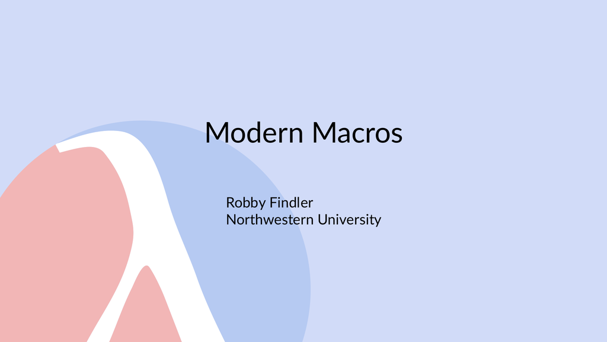

幻灯片 1：现代宏：Robby Findler，西北大学Slide 1: Modern Macros — Robby Findler, Northwestern University

**幻灯片文字 / Slide text**

[output not shown]

嗯，好。现在能用了吧？对，我想可以了。好，好，谢谢。抱歉，刚才真不好意思。好，现代宏系统的深处有一些命令式的东西。我们不会过多讨论它们，但它们确实存在。我先向大家道个歉。也许你们可以把这当成一个挑战；如果不愿意，至少我已经为此道过歉了。

Um, okay. Maybe is it working now? Yes, I think it is. Okay. Okay. Thanks. Sorry. Sorry about that. Okay. So, deep in a modern macro system, there's some imperative bits. Okay. We won't talk too much about those, but they're there. My apologies in advance. Maybe you can take this as a challenge, but if not, at least you have my apology about it.

第二件事是，很多特邀主旨报告都比较轻松，给你一个高层次的概貌，中间你看看电子邮件也没关系。这场报告的技术性稍强一些。不过，所需的背景知识只是对编程语言有一些了解。一般来说，你应该能顺利跟上这场报告。

Uh the second thing is that many invited keynotes are kind of these light airy things that sort of give you this high level thing and you can kind of check your email in the middle and it's going to be fine. This talk is a little bit more technical. So with that in mind I the background required is just some understanding of programming languages. Generally you should be able to follow the talk fine.

不过，如果你漏听了什么，或者有些事情对我来说太显然，以至于我忘了说，但你觉得奇怪，比如看到那么多括号感到困惑，尽管开口，打断我，我会解释。如果你觉得举手更自在，也可以举手。这些都没问题。好，那么我先从这场报告的核心论点说起。

Um, so but if you miss something or I don't say something because it's just sort of obvious to me and I forget to mention it but it's weird because of all the parenthesis or something like that just you know just say something stop me and I'll I'll explain it. Raise your hand if you feel more comfortable that way. That's all fine. Okay. So so with that let me start with the thesis of the talk. Okay.

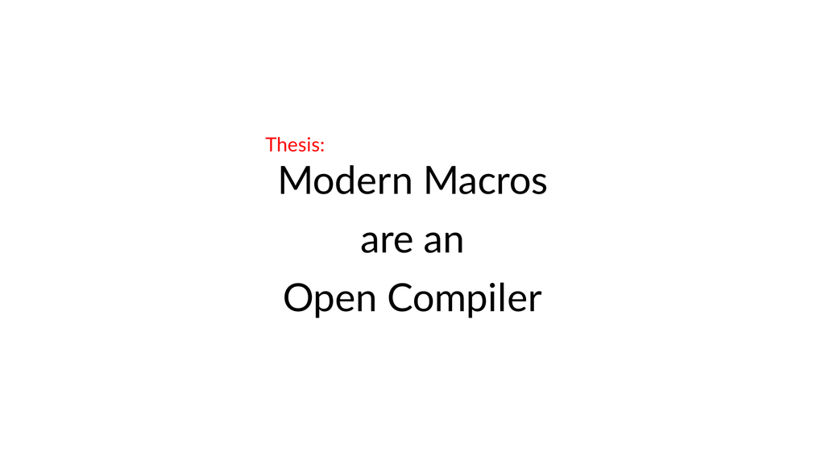

幻灯片 2：核心论点：现代宏是开放式编译器Slide 2: Thesis: Modern Macros are an Open Compiler

**幻灯片文字 / Slide text**

```
Thesis:
Modern Macros
are an
Open Compiler
```

现代宏就是一个开放式编译器。好，这是什么意思？这个说法可能有点晦涩。所以，让我花几分钟解释这个论点，希望之后你们能把它当作一句口号记住，记住我今天想说服你们接受的观点。说到宏，有多少人会想到 #define、cpp 或者 m4？有人吗？对，对，对，好。

Modern macros are an open compiler. Okay. What does that mean? It's maybe a little bit opaque. So, let me take a few minutes to explain what the thesis is and then hopefully you'll remember it as sort of a slogan for what I'm trying to convince you of today. Um, how many of you when I say macros think of hashdeine or cbp or m anybody? Yeah. Yeah. Yeah. Okay.

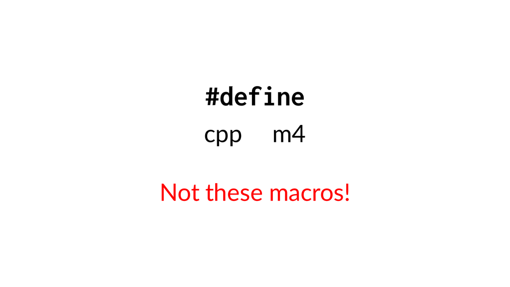

幻灯片 3：不是 #define、cpp 或 m4 那一类宏Slide 3: Not these macros: #define, cpp, and m4

**幻灯片文字 / Slide text**

```
#define
cpp
m4
Not these macros!
```

今天我们不能用这种思路来看宏。这些东西的工作方式是：程序员写下一个程序，某个工具介入，把它变成另一个程序，然后编程语言才开始参与。我们要讲的不是这个。这种思路可以追溯到五十年代中期。

This is the wrong headsp space to be in for today. Okay. These these things it's like the programmer writes one program, some tool comes in, changes it into a different program, and then the programming language gets involved. That's not what instead we should think of the this is like dates back to the mid 50s.

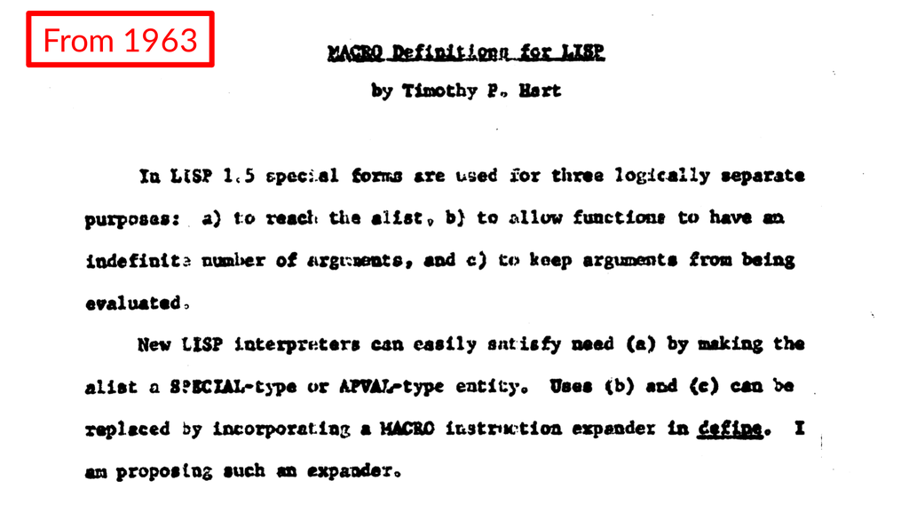

幻灯片 4：1963 年：宏是编程语言的一部分Slide 4: From 1963: macros as part of the programming language

**幻灯片文字 / Slide text**

```
From 1963
```

我们稍微往前跳一点，来到 1963 年，把这里看作现代宏系统的某种起点。这是一份大概两页的备忘录，一份 AI 备忘录。这里面有一点至关重要：宏是编程语言的一部分。好，有多少人听说过宏这个语境下的卫生性？好，很好。

We want to like let's skip forward a little bit to 1963 and think of this as kind of the root of the modern macro system. And this is a like a two page memo an AM memo where but one of the things that's essential in what's written here is that the macros are part of the programming language. Okay. So, how many of you have heard of hygiene in context of Okay, good. Good.

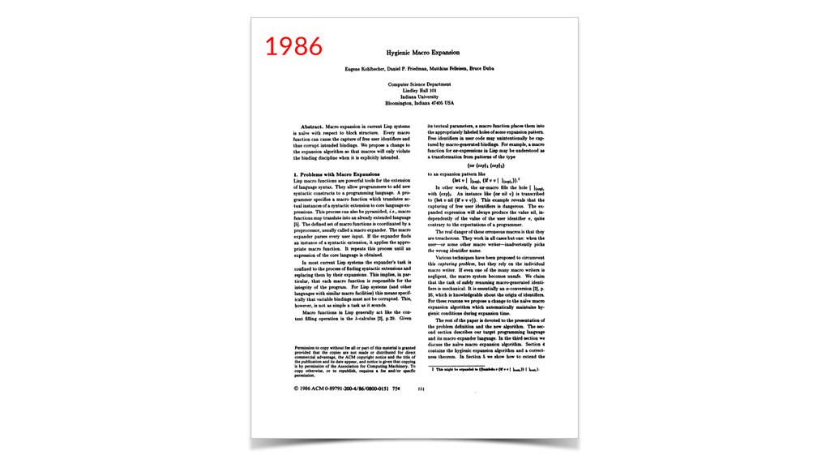

幻灯片 5：1986 年：卫生宏展开Slide 5: 1986: Hygienic Macro Expansion

**幻灯片文字 / Slide text**

```
1986
```

这是一篇技术上很深入、很有挑战性的论文。我听过有人把它概括为：他们为宏解决了 α 等价的问题。这个说法并没有错，算是一种合理的理解。但我想强调的是，如果你没有读过这篇论文，没有理解其中真正发生的事情，那么这项成果其实很不简单。从 1963 年那篇论文开始，大约经历了五次重大的进展，我们才走到今天现代宏所处的位置。

This is a technically deep challenging paper that I've heard people describe as they fixed alpha equivalents for macros which is not wrong. That's a reasonable understanding but what I want to emphasize is that this result if you haven't read the paper and understood what's really going on it's non trivial what's going on in there and there have been five sort of major steps forward from that 1963 paper that lead us to where modern macros are today.

[figure not shown]

幻灯片 6：三十年间的五项关键技术成果Slide 6: Five Deep Technical Results Over 30 Years

**幻灯片文字 / Slide text**

```
Five Deep Technical Results Over 30 Years
1986
1990
1992
2002
2016
```

## 从简单的解析器转向现代宏系统Changing from a simple parser to a modern macro system

所以，如果你了解一点卫生性，对 1986 年的工作也有一些直觉，我们当然可以沿着历史脉络，让你一路了解直到今天的进展，不过那可能有点绕远。如果大家愿意，我更希望你们换个方向，从编译器的角度来思考。

So, if you know something about hygiene and you have some intuition about what's going on in 1986, well, we could do the kind of historical thing to catch you up to the current the present, but that's maybe the long way round. And instead, what I would like you to do, if you'll indulge me, is to instead sort of orient yourself around thinking about compilers.

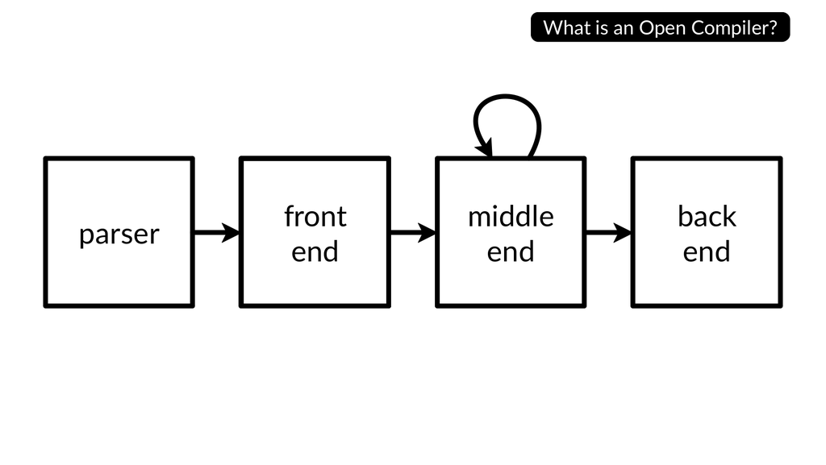

幻灯片 7：编译器结构：解析器、前端、中端、后端Slide 7: Compiler architecture: parser, front end, middle end, back end

**幻灯片文字 / Slide text**

```
What is an Open Compiler?
parser
front
end
middle
end
back
end
```

这里是一张编译器体系结构的示意图。我们有一个解析器，它把线性的字节序列转换成一棵树。

So here's a cartoon of a compiler architecture like a compiler architecture diagram cartoon where we have the parser which takes your linear sequence of bytes and turns it into a tree.

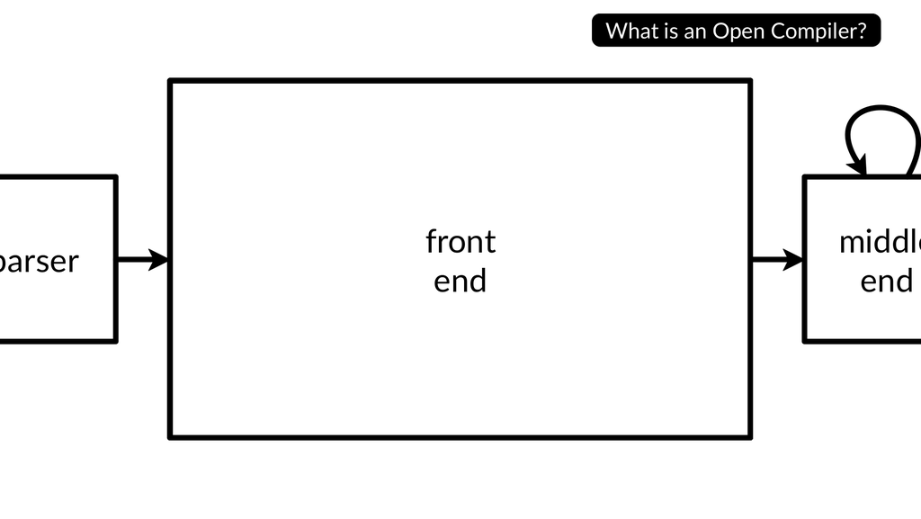

幻灯片 8：聚焦编译器前端Slide 8: Focusing on the compiler front end

**幻灯片文字 / Slide text**

```
What is an Open Compiler?
parser
front
end
middle
end
```

然后是前端，它把许多为人类提供便利的东西简化掉，转换成 IR。编译器领域的大部分研究都集中在这里；许多有趣的优化和其他事情都发生在这里。然后，我们生成一些汇编代码，让程序能够运行。在这个语境下，现代宏并不是把整个编译器都开放出来，而是为编译器提供一个开放的前端。

We have the front end which simplifies like a lot of human conveniences away into the IR where the compiler community for the large part lives and we like lots of fun optimization interesting things happen here and then we generate some assembly so we can run the program. Okay, in this context, modern macros are they're not an open entire compiler. They're an open front end to the compiler.

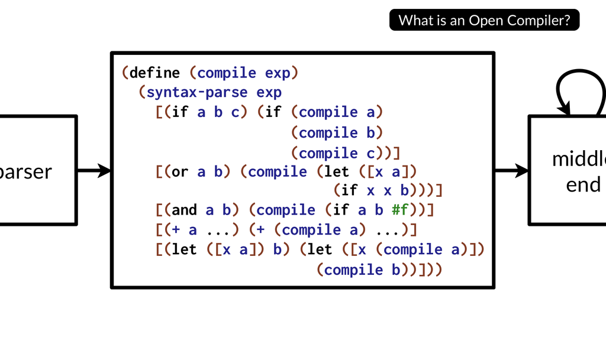

幻灯片 9：前端中的递归编译函数Slide 9: The recursive compilation function in the front end

**幻灯片文字 / Slide text**

```
What is an Open Compiler?
parser
(define (compile exp )
  (syntax-parse exp
  [(if a b c) (if (compile a )
(compile b)
(compile c ))]
[(or a b) (compile (let ([x a])
  (if x x b)) )]
[(and a b) (compile (if a b #f) )]
[(+ a ...) (+ (compile a ) ...)]
[(let ([x a]) b) (let ([x (compile a )])
  (compile b ))]))
middle
end
```

那么，我们暂且聚焦一下前端内部发生的事情。在前端里，有一个单体式的递归函数，把解析得到的形式转换成 IR 语言。现代宏系统带给你的观念是：这样一个只能全盘接受或者完全不用的整体，既不够灵活，也不够便于组合，因此很难轻松地构建新的编程语言。

So, let's focus in on what's going on in the in the front end for a moment. So, in the front end, you have some monolithic recursive function that translates just the parsed form down into that IR language. And what a modern macro system offers to you is the idea that this monolithic take it or leave it thing is not flexible enough, not composable enough to be able to easily build new programming languages.

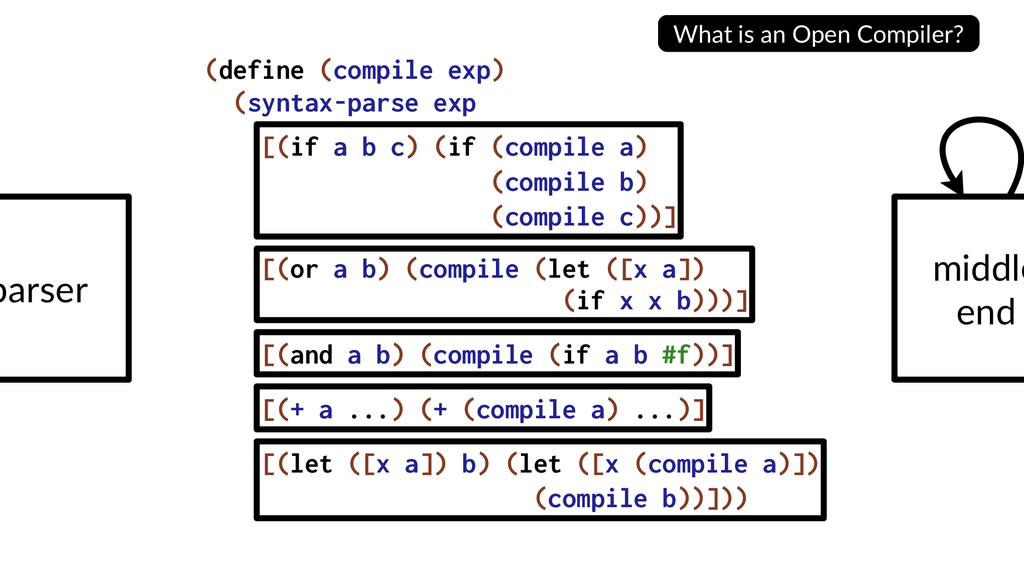

幻灯片 10：将各个编译分支视为独立组件Slide 10: Treating compilation cases as independent components

**幻灯片文字 / Slide text**

```
What is an Open Compiler?
parser
(define (compile exp )
  (syntax-parse exp
  [(if a b c) (if (compile a )
(compile b)
(compile c ))]
[(or a b) (compile (let ([x a])
  (if x x b)) )]
[(and a b) (compile (if a b #f) )]
[(+ a ...) (+ (compile a ) ...)]
[(let ([x a]) b) (let ([x (compile a )])
  (compile b ))]))
middle
end
```

相反，从我们希望达到的目标来看，我们想把这里的每一部分都看作独立组件，可以以某种方式选用或舍弃。我们就这样为编译器构建一个新的前端，从而得到一种新的编程语言。

And instead aspirationally, okay, what we want to think about is that each of these is an independent component that we can somehow take or leave. And that's how we're going to build a new front end to our compiler and get a new programming language.

这很符合 LLVM 的思路：放进去一个新的前端，就能复用中端里那些很棒的功能。而这里，我们想再往前走一步，希望能够把这些不同的分支混合搭配——不管这具体意味着什么。暂时先把它当成我们想实现的目标就好。

So very much in the spirit of LLVM where you put a new front end in, you can reuse all that good stuff that's happening in the middle end and here we want to say okay we want to take that one step further where we want to be able to sort of mix and match cases whatever that means. Okay, just take this as aspirationally for now.

随着报告的展开，我们会深入探究，理解这到底是什么意思。不过，先想象一下：我可以从一种已有的编程语言里拿出几个构造，再把它们和另外几个有些不同的构造组合起来。

We're going to dig into that and understand what that means as we go through the talk. But just imagine, you know, I could take like a couple of constructs in some programming language that's already there, put them together with a couple of constructs that are sort of different.

也许再扔掉一些不适合我正在构建的特定语言的构造，这样就得到一个新前端，进而得到一整门新的编程语言。

Maybe throw away a few that don't make sense for the particular language I'm building and get a new front end and then a new entire programming language out of it. Okay.

在介绍技术上如何实现这一点之前，我先展示几种我们在 Racket 中拥有的编程语言。Racket 就是现代宏系统的一个实例。这能让你们感受一下，可能性的范围到底有多大。有人了解同步响应式编程吗？Esterel？对，听说过，是吧，稍微了解一点。好。

Um let me just before we get into like how we're going to achieve that technically let me just show you some programming languages that we have in Racket which is an instance of a modern macro system just to give you a feel for the sort of space of possibilities. Okay. So anybody know synchronous reactive programming? Eststerl. Yeah, you heard of okay a little bit. Okay.

演示代码：同步响应式编程：信号、发射与并行组合Demo code: Synchronous reactive programming: signals, emission, and parallel compositionreactor.rkt

```
#lang reactor

(define-signal input)

(define/contract (counter input chan)
  (reactive-> pure-signal? value-signal? none/c)
  (emit& chan 0)
  (loop&
   (await& #:immediate input)
   (emit& chan (add1 (last chan)))
   pause&))

(define/contract (printloop chan)
  (reactive-> value-signal? none/c)
  (loop&
   (await& chan
           [times
            (printf "got total of ~a inputs\n" times)])))

(define/contract (main input)
  (reactive-> pure-signal? none/c)
  (define-signal crosstalk 0 #:gather +)
  (par& (counter input crosstalk)
        (printloop crosstalk)))

(define r (prime main input))
(react! r)
(react! r)
(react! r input)
(react! r)
(react! r)
(react! r input)
(react! r)
```

在这个语言家族、这个社区里，有一种语言叫 ReactiveML。而这个可以叫作 Reactive Racket。它是一门编程语言，具有时刻、通道、发射、并行组合等概念，也就是同步响应式编程所具备的那些东西。

So there's a there's a language in that family in that community called reactive ML. This is could be named reactive racket. So it has it's a programming language that has a notion of instance and channels and emission and parallel composition and all the stuff that you get with synchronous reactive programming.

但是，它的语义与你通常预期的很不一样。这并不是说它就像 Racket；虽然这里有很多括号，但这门编程语言的语义与 Racket 的语义相当不同。这是一例。再看另一门编程语言。这门语言是 Sorawee Porncharoenwase 实现的，他是华盛顿大学的一名博士生。报告后面我还会说到他。当时他正在一本数学教材里学习哥德尔的递归函数。当然，这里面其实藏着一门编程语言，所以他就把它实现出来，用同样的这些技术把它加了进来。

But it's so the semantics is really quite different than what you would expect in you know this is not like racket okay there's a lot of parenthesis here but the semantics of this programming language is quite different than what it is and so that's one here's another programming language this programming language was implemented by Sorowi who's a PhD student at the University of Washington I'll return to him later in the talk and he was studying Girdle's recursive functions in some math textbook and of course there's a programming language hiding inside there so he implemented it and added it using this same technique techniques.

演示代码：递归函数语言：加法、乘法与阶乘Demo code: The recursive-function language: addition, multiplication, and factorialrecursive.rkt

```
#lang recursive-language

import Pr, Cn, s, id, z, const;

sum = Pr[id_1^1, Cn[s, id_3^3]];
print sum(2, 23); # should be 25

prod = Pr[z, Cn[sum, id_1^3, id_3^3]];
print prod(3, 3); # should be 9

fact =
  Cn[Pr[const_1, Cn[prod, Cn[s, id_2^3], id_3^3]],
     id_1^1, id_1^1];

print fact(fact(3)); # should be 720

print fact(Cn[s, s](4)); # should be 720

check fact(3) = 6;
```

所以，这同样是在 Racket 内部运行，使用 Racket 的中端和后端。通过开放的前端，我们现在就可以用哥德尔递归函数来做一些事情，比如计算阶乘之类的。你们认得这门编程语言吗？看起来眼熟吗？教过编程入门课的人都知道，每一门专业的编程语言对初学者来说都布满了大坑，对吧？

So this again is running inside racket inside the using the back the middle end and back end of racket and through the open front end we're now doing I don't know some factorial functions using girl recursive functions. Um you recognize this programming language. Does this look familiar at all? Um, anybody who's taught introductory programming knows that every professional programming language is full of gaping pit holes, pitfalls for beginning students, right?

## 把 Python 改造成一种新语言Changing the language from Python to a new one

演示代码：DSSL2：面向数据结构课程的语言Demo code: DSSL2: a language for a data-structures coursedssl2.rkt

```
#lang dssl2

struct node:
    let key
    let left
    let right

def insert(t, k):
    if t is None:
        t = node(k, None, None)
    elif k < t.key:
        t.left = insert(t.left, k)
    elif k > t.key:
        t.right = insert(t.right, k)
    return t

insert(insert(None,5),6)
```

里面有很多东西都是为了让专业程序员用得顺手而设计的，学生却会一头掉进这些坑里，情况很糟糕。所以，这门编程语言采用与 Python 相同的表面语法，但去掉了许多会造成这些陷阱的东西，又添加了不少内容。西北大学的数据结构与算法课程就在使用它。

There's just lots of stuff in there that's designed to make the professional's life work well and students just fall into these things and it's terrible. So this is a programming language that has the same surface syntax as Python but throws away a bunch of the things that lead to these pitfalls and adds a bunch of stuff in and it's used in the data structures and algorithms course at Northwestern University.

它添加了很多东西，以便研究他们希望在那门课里教授的内容，同时又去掉了许多不需要的东西。这样一来，就能在那些原本不使用的功能所处的位置，提供有帮助的错误消息。还有，既然我们来到了 PADL，这里面当然也有一个 Datalog。耶！好。

So it adds a bunch of stuff in to be able to study the kinds of things that they want to be able to teach there and then throws away a bunch of stuff that they don't need and that therefore lets them kind of place helpful error messages in place of those things they weren't using. Um, and just because we're at paddle, there's a d there's a data log in here, too. Yay. Okay.

演示代码：Datalog：祖先关系查询Demo code: Datalog: querying the ancestor relationdatalog.rkt

```
#lang datalog

ancestor(A, B) :- parent(A, B).
ancestor(A, B) :-
  parent(A, C),
  ancestor(C, B).

parent(john, douglas).
parent(bob, john).
parent(ebbon, bob).

ancestor(A,B)?
```

那个我就不需要向各位介绍了。好，这些就是采用开放前端这一想法能做到的一部分事情。而且，这些语言的实现成本相对较低。

I don't need to tell you guys about that one. Um, all right. So, that's that's some of the things that you can do with this idea of having an open front end and getting and these are relatively inexpensive to implement.

## 现代宏中的控制问题Control Issues in Modern Macros

我的意思是，它毕竟还是一门编程语言，仍然需要投入工作。但因为能够在编译器前端里混合搭配这些分支，实现这些语言时就能进行大量复用。

I mean it's still a programming language you know there's still work required there but because of the ability to kind of mix and match cases here in this compiler in the front end you can get a lot of reuse when you're implementing these languages. Okay.

所以，要理解如何实现这个开放式编译器，并让它真正工作，我们需要讨论三类技术问题。首先是这个有趣的递归函数里的控制问题，其次是数据问题，还有一个依赖管理方面的整体图景；随着讲解推进，我会说明为什么需要它。那么先从控制开始。

So there are sort of three things that we need to talk about technical things that we need to talk about to see how to achieve this open compiler and get it to work. There's the control issues here in this interesting recursive function. There's data issues here and then there's sort of a dependency management picture which I'll motivate as we go. So let's start with control.

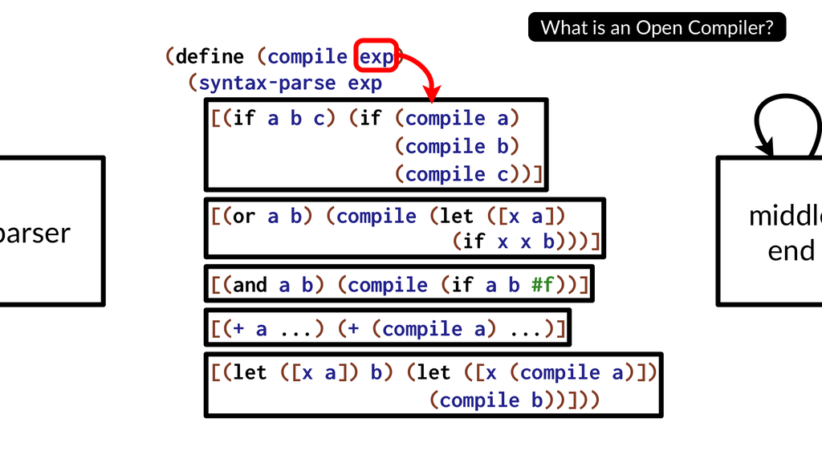

幻灯片 11：先识别并处理 if 分支Slide 11: Identifying and processing an if case

**幻灯片文字 / Slide text**

```
What is an Open Compiler?
parser
(define (compile exp )
  (syntax-parse exp
  [(if a b c) (if (compile a )
(compile b)
(compile c ))]
[(or a b) (compile (let ([x a])
  (if x x b)) )]
[(and a b) (compile (if a b #f) )]
[(+ a ...) (+ (compile a ) ...)]
[(let ([x a]) b) (let ([x (compile a )])
  (compile b ))]))
middle
end
```

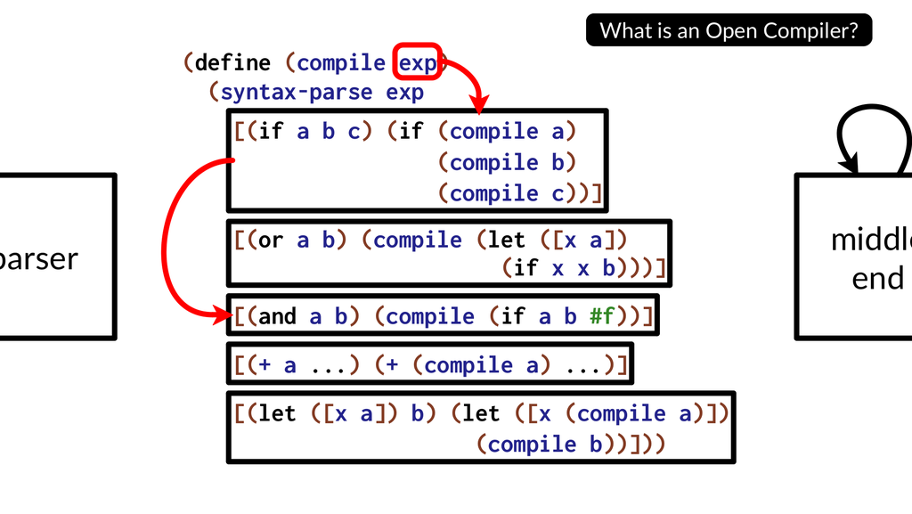

**幻灯片文字 / Slide text**

```
What is an Open Compiler?
parser
(define (compile exp )
  (syntax-parse exp
  [(if a b c) (if (compile a )
(compile b)
(compile c ))]
[(or a b) (compile (let ([x a])
  (if x x b)) )]
[(and a b) (compile (if a b #f) )]
[(+ a ...) (+ (compile a ) ...)]
[(let ([x a]) b) (let ([x (compile a )])
  (compile b ))]))
middle
end
```

如果有人传进来一个表达式，比如一个 if 表达式，我们就进入第一个分支。它的某个子表达式可能又是一个 and 表达式。你可以看到，and 表达式实际上只是三元 if 的一种简写。所以我们会绕回来处理那个 and，然后它里面也许还有一个 let 表达式。

So if someone passes in an expression and maybe it's an if expression so we go in that first case and then maybe a sub expression of that's an and expression. And you can see like and expressions are really just a shorthand for a turnary if. So we're going to go back around and and that one and then maybe there's a lead expression inside there.

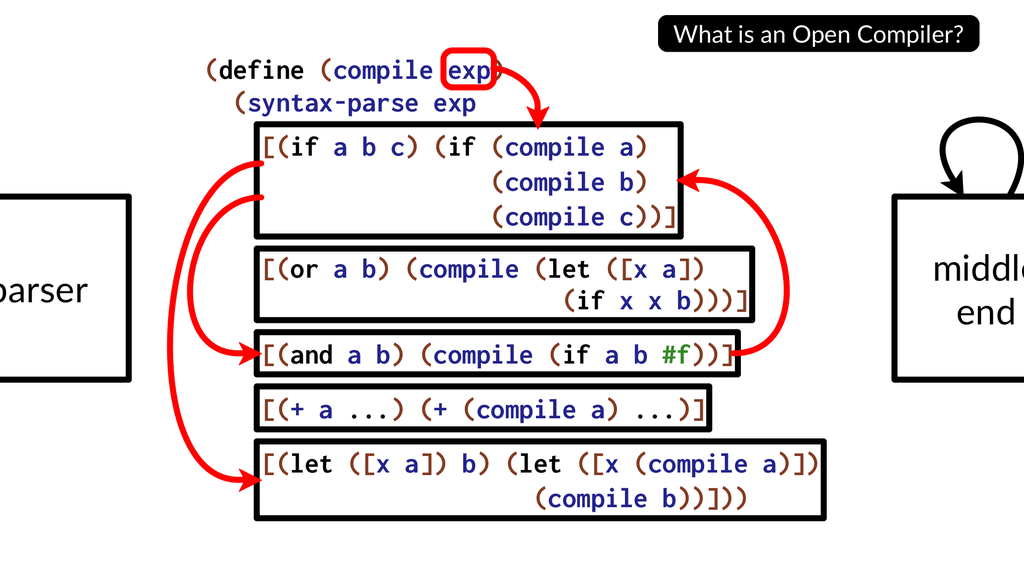

幻灯片 13：递归处理嵌套的 let 分支Slide 13: Recursively processing a nested let case

**幻灯片文字 / Slide text**

```
What is an Open Compiler?
parser
(define (compile exp )
  (syntax-parse exp
  [(if a b c) (if (compile a )
(compile b)
(compile c ))]
[(or a b) (compile (let ([x a])
  (if x x b)) )]
[(and a b) (compile (if a b #f) )]
[(+ a ...) (+ (compile a ) ...)]
[(let ([x a]) b) (let ([x (compile a )])
  (compile b ))]))
middle
end
```

这个函数在完成工作时，其实发生了许多事情。我们需要把它们一一梳理出来，思考现代宏系统如何帮助我们自动完成其中一部分，只给我们留下空间，填入自己的编程语言中有趣而独特的部分。下面把这些事情列出来。

And there's so there's a lot of sort of things happening in the way this function is doing its job that we need to tease out and think about as how the modern macro system can help us automate some of this and leave us just the space to put in the parts that are interesting and different about our programming language. So here's an enumeration.

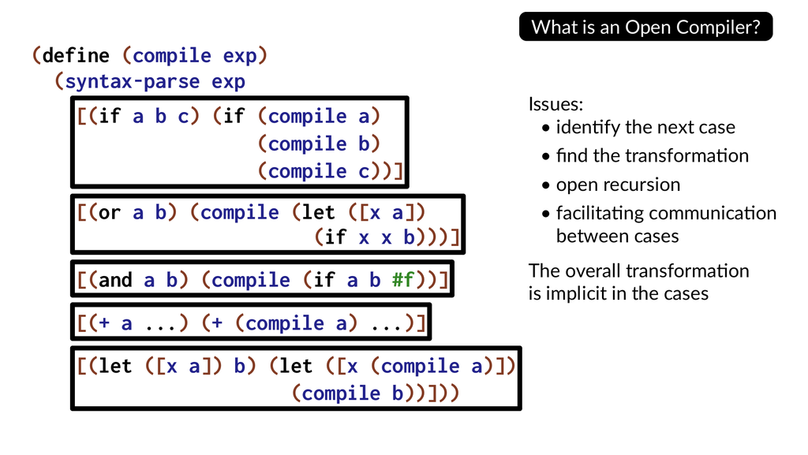

幻灯片 14：控制问题：分支识别、转换、开放递归与通信Slide 14: Control issues: cases, transformations, open recursion, and communication

**幻灯片文字 / Slide text**

```
What is an Open Compiler?
(define (compile exp)
  (syntax-parse exp
  [(if a b c) (if (compile a)
(compile b)
(compile c))]
[(or a b) (compile (let ([x a])
  (if x x b)))]
[(and a b) (compile (if a b #f))]
[(+ a ...) (+ (compile a) ...)]
[(let ([x a]) b) (let ([x (compile a)])
  (compile b))]))
Issues:
• identify the next case
• find the transformation
• open recursion
• facilitating communication
between cases
The overall transformation
is implicit in the cases
```

在处理过程中，我们必须识别接下来是哪一种情况，必须找到针对这一情况的转换。可以看到，这些递归调用是在方框里面的，所以在这些部分之间，以某种方式发生着递归。而且，这种递归并不是任意进行的，而是具有非常明确的结构。

We have to as we work through we have to identify the next case. we have to find the transformation for that particular case. There's you can see that these recursive calls are kind of inside the boxes. So there's some kind of a recursion happening through these things in some way and it's not happening in an arbitrary way. It's actually happening in a very structured way.

因此，我们不会把这项操作交给编写方框内部内容的人，而是会自动替他们完成，也就是那个递归驱动器。写过编译器前端的人都知道，有时某种构造中，程序员写下的某个外层内容会影响某个内层内容的编译，也就是语法上嵌套在里面的内容，对吧？因此，我们需要某种促进通信的方式。

So we're not going to give that operation to the person who's writing the content of the boxes. That's going to be happening automatically for them. That sort of recursive driver. Um, anyone who's written a front end to a compiler knows that sometimes you have constructs where some outer thing that the programmer has written affects the compilation of some inner thing like syntactically inside, right? And so we need some way to facilitate communication.

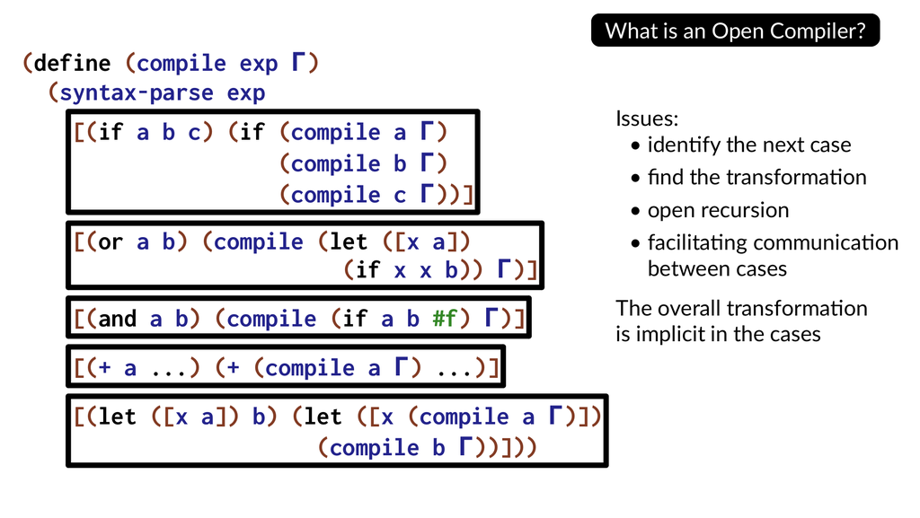

幻灯片 15：在编译过程中逐层传递环境 ΓSlide 15: Threading the environment Γ through compilation

**幻灯片文字 / Slide text**

```
What is an Open Compiler?
(define (compile exp Γ)
  (syntax-parse exp
  [(if a b c) (if (compile a Γ)
(compile b Γ)
(compile c Γ))]
[(or a b) (compile (let ([x a])
  (if x x b)) Γ)]
[(and a b) (compile (if a b #f) Γ)]
[(+ a ...) (+ (compile a Γ) ...)]
[(let ([x a]) b) (let ([x (compile a Γ)])
  (compile b Γ))]))
Issues:
• identify the next case
• find the transformation
• open recursion
• facilitating communication
between cases
The overall transformation
is implicit in the cases
```

通常会有某种环境，或者某个累积参数，把上下文信息带进来，从而影响嵌套内容的编译。因此，我们需要做一些事情来支持这种机制。

There's typically like, you know, some environment, some accumulator parameter that's carrying some information about the context in so it affects compilation for nested things. So that's the we need to do we need to do something to help support that.

最后这一点，从编译器及其前端的角度看，其实很显然；但深入宏的具体分支时，却很容易忘记：当你要把解析器产生的程序送往中端时，实际上只有一件事可做，那就是把它转换成中间语言。

And then this last point here it's sort of obvious when you think about it from the perspective of a compiler and the front end to a compiler but when you start to get into the specific cases in a macro it can be easy to forget and that is there's only one way there's only really one thing you can do with a program that came out of the parser when you're on your way to the middle end and that is transform it into the middle language.

对吧？外面的东西可能完全是另一门语言。我们对这些子表达式中发生的事情一无所知。这些部分应该彼此通信，但我们应该专注于一个组件，只实现这个组件。那么，某个具体情况下，子表达式会做什么？答案只能是：语言规定它们做什么，它们就做什么。

Right? You you it's like a totally different language out there. We don't know anything about what's happening in these subp expressions. These guys are supposed to communicate with each other, but we're supposed to have our focus on one component and implementing one component. So, what the sub expressions are going to do in a particular case, well, it's like, well, they do whatever the language is going to do.

你真正能对它们做的，只有把它们转换成那门已知的语言，然后也许查看一下结果。所以，在某种意义上，你并不知道其他所有宏都在做什么。这正是宏系统实现组合的关键。如果你选取其中四个，又加入三个，再去掉七个，不管怎样，最后剩下什么就是什么。

The only thing you can really do with them is just transform them into that well known language and then maybe look at that. So, you don't know anything somehow about what all the other macros are doing. And that's kind of key in the way the macro system composition is happening. If you're going to take four of these and add three more and should drop seven of them, you know, whatever what's left what's left.

## 改变语言Changing Language

你只需要把它展开成中端的 IR 语言，就能知道这个程序在做什么。没有任何声明会告诉你它在做什么。对，对，对。错误报告这些事情，我们肯定会讲到。

Well, I you know, you just expand it into the into the into the middle end IR language and find out what that program does. There's not any declarations about what it's doing. Yeah. Yes. Yes. Yes. We will come to error reporting and these things for sure.

不过，当你的视角只局限于一个分支时，你并不知道全局情况。而你实现的这个分支也许要在多种语言中复用，所以你并不知道自己会被用在哪里。

So but when your perspective is in just one case then you sort of don't know and you're implementing that one case to be reused maybe in multiple languages you sort of don't know where you're being used.

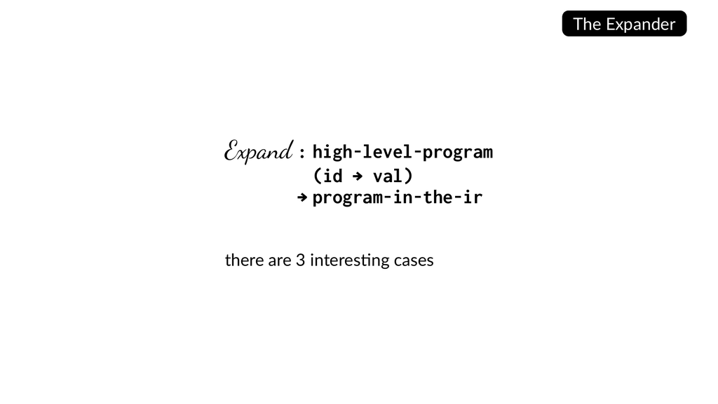

幻灯片 16：展开器的输入、环境和输出Slide 16: The expander: input, environment, and output

**幻灯片文字 / Slide text**

```
The Expander
Expand : high-level-program
(id → val)
→program-in-the-ir
there are 3 interesting cases
```

因此，我所说的整体转换就是这个意思：你不知道自己处于哪一种上下文里，没有任何这方面的信息。你真正能做的，只有执行转换，或者转换失败。好，展开器就是负责处理所有这些事情的工具。对于 expand，我们给它一个高层次程序，也就是刚从解析器出来的东西；再给它一个环境，记作 γ。这个 γ 也会包含我们执行此次展开时处于活动状态的宏。

So that's the sense with which I mean sort of the this overall transformation is you don't know which one you're in the context of right you don't have any information about that all you can really do is go do the transformation or fail to do the transformation okay so the expander is the tool that handles all this handles all that stuff so expand we give it a high level program something that just came out of the parser we give it an environment that's a gamma that gamma is also going to have that macros that are active as we're doing this expansion.

哦，我刚才没有说，这里的每一个方框——好，也许大家已经猜到了——都是一个宏定义。每个方框都将是一个宏定义。好。那么，最初这个环境里会有一组全局宏，而我们也会利用这个环境来帮助各部分通信。

Oh, I didn't say each of these each of these boxes. Okay, maybe you kind of intuited that already. The these are macro definitions. These are going to be the macro definitions each of these boxes. Okay. All right. So we'll initially have we'll initially have like sort of a set of global macros that are in this environment and we'll also use it we'll also use this environment to help facilitate communication.

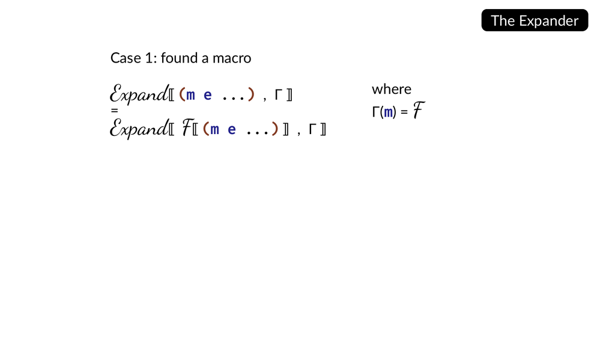

幻灯片 17：情况一：找到一个宏调用Slide 17: Case 1: found a macro application

**幻灯片文字 / Slide text**

```
The Expander
Case 1: found a macro
Expand〚 (m e ...) , Γ ⟧
=
Expand〚 F〚 (m e ...) ⟧ , Γ ⟧
where
Γ(m) = F
```

所以，它在这里扮演两个角色，最后我们得到一个完全处于 IR 中的程序。谢谢。好，这里有三种有趣的情况。第一种，我们找到了一个宏。也就是说，有一个表达式，左括号后面紧接着一个标识符；这个标识符在 γ 的定义域中。我们查找它，发现那里有一个函数。

So it'll play two roles here and then we get back a program that's fully that's in the in the IR. Thank you. The okay so there's three interesting cases here. First case we found a macro. So we have some expression where there's an identifier right after an open PN and that identifier is in the domain of gamma and we look it up and we find a function some function there.

好，这个函数就是转换操作。它将是一个任意的 Racket 函数，可以做任何它想做的事情，然后转换这个表达式。我们拿到这个表达式，把它交给这个函数，再对它产生的东西重新开始展开过程。所以，现在我们实际上是在执行其中一个分支，而找到这个分支的方式就是查找。

So okay that's the transformation and now this is going to be an arbitrary racket function right it can just do whatever it wants to do and then it's going to transform this expression so we'll take this expression give it to it and then we'll just start the expansion process over again with whatever it produces. So this is like the we're actually doing one of the cases now and we found it because we looked it up.

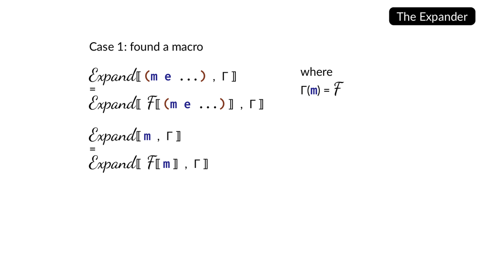

幻灯片 18：单独出现的标识符也可能触发宏Slide 18: An identifier alone can also invoke a macro

**幻灯片文字 / Slide text**

```
The Expander
Case 1: found a macro
Expand〚 (m e ...) , Γ ⟧
=
Expand〚 F〚 (m e ...) ⟧ , Γ ⟧
where
Γ(m) = F
Expand〚 m , Γ ⟧
=
Expand〚 F〚 m ⟧ , Γ ⟧
```

我们在环境中查找了这个名字。另外，如果遇到一个在环境中有绑定、但并不紧跟左括号的名字，也会发生这种情况。它可能处于表达式的其他位置，并不紧跟左括号。对，对，对。我只是想说明，这里存在两个层次。这里这个东西，可以把它看作一棵树。

We looked up this name in the environment. Um this can also happen if we encounter a name that's bound in the environment that's not immediately following an open PN. So it's somewhere else in an expression not immediately following. Yeah. Yeah. Yeah. Yeah. I just wanted to make it clear there sort of two levels here. There's a Yeah. This this thing right here is think of this like a tree.

好，这个东西是一棵树，里面有某个序列，而树的第一个子节点是一个标识符。另一个东西则是一棵只有叶节点的树。对。所以，我们把这棵树传给从环境中查到的函数。它返回一个新东西，执行一次转换。然后我们就对那个结果继续处理。对。

Okay, this thing is a tree where we have some some sequence of stuff and an identifier in the first subchild of the tree. And then this thing is a tree that's a leaf node. Yeah. So we take that tree and we pass it into this function we got out of the environment. It gives us back a new thing. It does a transformation. Then we just continue on with that. Yep.

这些函数都是用 Racket 编写的任意代码。Racket 是一门命令式编程语言，所以它们可以通过某种全局状态彼此通信。这听起来像是一个糟糕的主意。不过，系统实际上对这些函数能够访问的状态进行了一定管理，因此在某些情况下，这个主意并没有那么糟糕。

Um, so these functions are arbitrary code written in Racket. Racket's an imperative programming language. So, one thing they can do is they can communicate with each other through some kind of global state. This sounds like a terrible idea. Um, there's actually some management of the state that's act that's available to these functions that makes that not such a terrible idea in some situations.

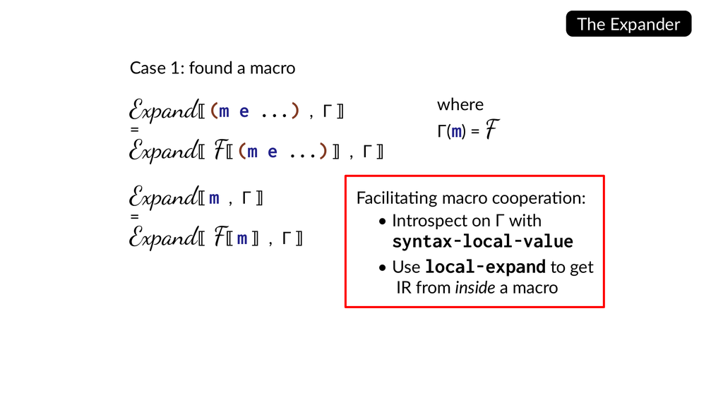

幻灯片 19：宏的协作：syntax-local-value 与 local-expandSlide 19: Macro cooperation: syntax-local-value and local-expand

**幻灯片文字 / Slide text**

```
The Expander
Case 1: found a macro
Expand〚 (m e ...) , Γ ⟧
=
Expand〚 F〚 (m e ...) ⟧ , Γ ⟧
where
Γ(m) = F
Expand〚 m , Γ ⟧
=
Expand〚 F〚 m ⟧ , Γ ⟧
Facilitating macro cooperation:
• Introspect on Γ with
syntax-local-value
• Use local-expand to get
 IR from inside a macro
```

我不会解释为理解其工作原理而需要的那些设置，你们只要知道，这并不总是一个糟糕的主意就行了。这是这些函数彼此通信、相互协作的一种方式。不过，展开器还明确提供了另外两种方式。我来介绍一下。你可以内省 γ。

And I'm not going to explain sort of the setup to know how that works, but just know that's not always a terrible idea. Um so that's but that's one way that these functions can communicate with each other and cooperate. But the expander explicitly facilitates two other ways to do it. So let me just tell you what those are. Um you can introspect on gamma.

对于这里这个 Racket 函数，Racket 有一个叫 syntax-local-value 的原语。展开器在幕后与 syntax-local-value 配合：如果你给它一个标识符，它就会到 γ 中查找，然后把 γ 中的值返回给你。这就是你获取外层某个东西为你放入的信息的方式。

So this racket function that you have here, there's a primitive in racket called syntax local value. And the expander is kind of cooperating behind the scenes with that function syntax local value where if you give it an identifier, it just looks it up in the gamma and gives you the value back in the gamma. So that's how you can retrieve information that some outer thing has put for you.

我们还没有看到怎样把信息放进去，但只要信息被放进去了，你就能到这个 γ 中查找。展开器在遍历这个项的过程中，会维护这个环境。你能做的另一件事，与我前面强调的那一点有关。

Okay, we haven't seen how to put information in yet, but if it gets put in, you can look it up in this gamma. Okay, that the expander is man maintaining as it works through the term. The other thing you can do is related to that sort of point I stressed earlier.

如果你负责转换某个形式，而其中有一个特定的子表达式，你可以要求把它完全展开成 IR。IR 是一门已知的语言，所以你就可以查看结果，做一些处理；这可能影响你决定如何编译其他部分。换句话说，作为这次转换的一部分，你可以对子表达式调用一次递归的、完整的展开过程，然后利用得到的结果、从中获取的信息，决定如何完成当前要求你对这个特定形式进行的整体转换。

Um if you have some sub expression that you that you're responsible for transfer you're responsible for transforming some form and there's a particular sub expression in it you can ask that be fully expanded and then sort of into the IR and which is a well known language and then you can kind of look at it and do stuff and that might affect how you choose to make other compilations and so you can so in other words you can sort of invoke a sort of recursive expansion entire expansion process on a sub expression as part of this transformation and then use that what you get information you get out of that to decide how to do the overall transformation that you're being asked to do for this particular form here.

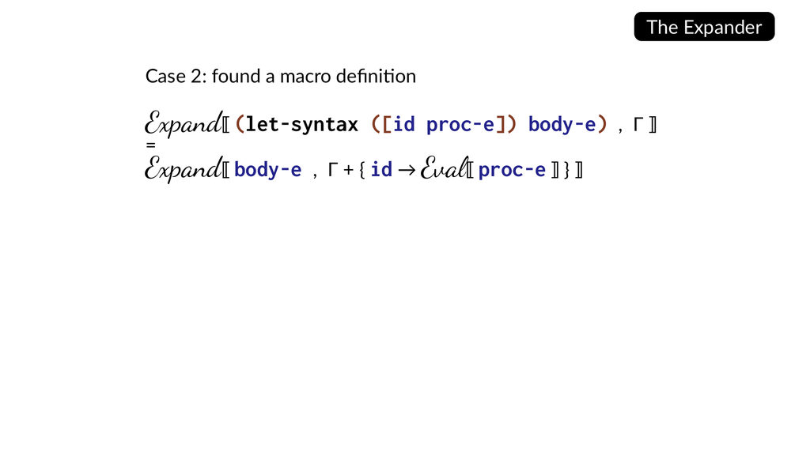

幻灯片 20：情况二：找到宏定义 let-syntaxSlide 20: Case 2: found a let-syntax macro definition

**幻灯片文字 / Slide text**

```
The Expander
Case 2: found a macro definition
Expand〚 (let-syntax ([id proc-e]) body-e) , Γ ⟧
=
Expand〚 body-e , Γ + { id → Eval〚 proc-e ⟧ } ⟧
```

这就是展开器帮助这些函数相互协作的两种方式。好，第二种情况，我们发现了一个宏定义。宏定义的写法是：写下 let-syntax，再写宏的名字，再写执行转换的函数。随后，这个转换就会在这个表达式内部生效。所以，它相当于一个局部宏。

So those are the two ways that the expander facilitates cooperation between these functions. Um okay, case two, we found a macro definition. So the way you write a macro definition is you say let syntax then you put the name of the macro then you put the function that does the transformation and then you the transformation will then be active inside this expression. So it's like a local macro.

我们先用某些全局宏初始化 γ，然后在展开过程中，可能遇到一些只在项的一部分中使用的宏。我们就是这样向 γ 添加内容的。好，现在请大家注意这里的 eval。我们稍后会回到这个 eval，因为这里还有一些微妙之处需要说明。不过，这个东西是一棵树，对吧？

So we we seed gamma with some kind of global macros and then as we're doing the expansion process we might encounter some macros that are only being used in part of the term and then that's how we add things to gamma. Okay. Now, I want to call your attention to this eval here. Um, we're going to return to this eval because there's some subtle points to be said here, but this is like a tree, right?

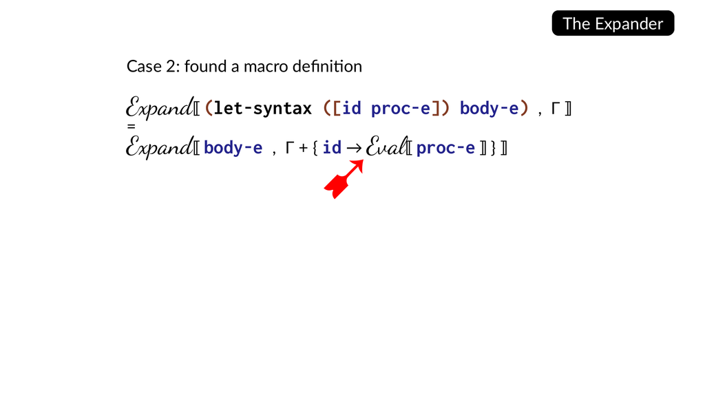

幻灯片 21：对 proc-e 求值，获得编译期的值Slide 21: Evaluating proc-e to obtain a compile-time value

**幻灯片文字 / Slide text**

```
The Expander
Case 2: found a macro definition
Expand〚 (let-syntax ([id proc-e]) body-e) , Γ ⟧
=
Expand〚 body-e , Γ + { id → Eval
➹
〚 proc-e ⟧ } ⟧
```

它是我们正在处理的项，是展开器的输入。因此，我们需要把它真正转换成一个值：如果它是宏转换器，那就应该是一个之后可以调用的函数。这就是这个 eval 做的事情。它把这棵树变成一个真正的值，让我们能在展开过程中使用它。

This is a term we're processing that's an input to the expander. So, we need to actually turn it into a real value that's a function we can do some we could call later if it was a macro transformer. So, that's what this aval is doing. It's taking that tree and making an actual value that we can sort of use as part of the expansion process.

而这个值不一定必须是函数，因为它也许只会通过 syntax-local-value 来使用。因此，你可以用这种方式放入一些与上下文有关、以后可能需要查询的东西，其他宏就能查出并使用它们。这一点可能还有些晦涩，暂时只要知道这是一件你可以做的事情就好。

Um, and this value doesn't have to be a function because it might only be used with that syntax local value. So, this is the way that you can put stuff that you might look up later about your context that other macros can then look up and then use. And this probably seems a little bit opaque, but maybe just for the moment understand it as a possible thing you can do.

稍后我会展示一些编程语言，再回头指出这里，说明为什么你会想这样做。好。那是在什么环境中呢？这正是我们需要回头再讲这个 eval 的主要原因。让我先讲完展开器的三种情况，然后再来讨论。对，对，这个问题非常好，非常好。好，最佳问题。你获得了今天的最佳提问奖。

And I'll show you some programming languages and point back to this to see why you want to do that later. Okay. And what environment is that? This is this is the this is the main reason we need to return to this aval. So let me finish the three cases of the expander and then Yeah. Yeah. That's very good. Very good. All right. Best question. Okay. You win the best question award today. Um okay.

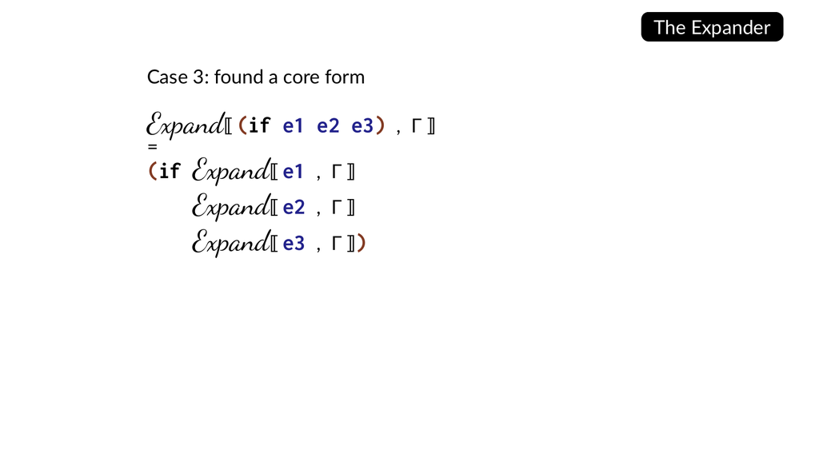

幻灯片 22：情况三：展开器认识核心形式并递归展开Slide 22: Case 3: recursively expanding a known core form

**幻灯片文字 / Slide text**

```
The Expander
Case 3: found a core form
Expand〚 (if e1 e2 e3) , Γ ⟧
=
(if Expand〚 e1 , Γ ⟧
Expand〚 e2 , Γ ⟧
Expand〚 e3 , Γ ⟧)
```

那么，最后一种情况是发现了一个核心形式。它不是宏定义，我们也没有在引入局部宏。因此，剩下的只能是这门已知的 IR 语言中的东西。而展开器认识这门语言，所以它知道如何向内部递归。

So so uh then the final case is you found a core form. So it's not a macro definition. We're not introducing a local macro. So the only things that are left are things in this well known IR language. And the expander knows that language. So it knows how to recur inside.

这里的 if 只是一个例子。我不确定具体数量，Racket 的版本大概有八到十种这样的核心形式。根据这个核心语言的具体结构，它会决定：好，在这个位置执行递归，递归处理内部内容。这就是展开器的三种情况。

So this is just one example if but there's I don't know there's like eight or 10 examples eight or 10 things that are in the racket version that are the core forms and it and based on the structure of whatever this core language is it just sort of like okay I'm going to do the recursion at this point and recur inside. So those are the those are the three cases of the expander.

好，控制方面就是这样。我们来谈数据。对，核心内容属于这门已知的、公开规定的语言。如果你查阅 Racket 文档，它叫作完全展开形式。它扮演的角色与 LLVM 中的 IR 相同，是所有东西最终编译到的一门已知语言。对，所以展开器必须确切地认识这门语言，才能做这些事情。就是这样。

Okay so that's the control story. Let's talk about data. Yeah, the core things are in this well known published language that if you look in the racket docs, it's called the fully expanded form. It plays the same role as the IR and LLVM. It's like this well known language that everything is compiling into. Yeah. So, the expander has to know what that language actually is to be able to do that. So, yeah.

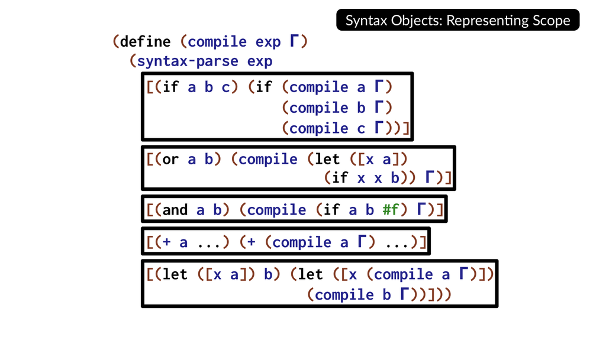

幻灯片 23：从控制流程转向语法对象Slide 23: From control flow to syntax objects

**幻灯片文字 / Slide text**

```
Syntax Objects: Representing Scope
(define (compile exp Γ)
  (syntax-parse exp
  [(if a b c) (if (compile a Γ)
(compile b Γ)
(compile c Γ))]
[(or a b) (compile (let ([x a])
  (if x x b)) Γ)]
[(and a b) (compile (if a b #f) Γ)]
[(+ a ...) (+ (compile a Γ) ...)]
[(let ([x a]) b) (let ([x (compile a Γ)])
  (compile b Γ))]))
```

其实，我原本还想提一下 Michael Ballantyne。你的这个问题正好给了我提到他的机会。我本来想介绍他参与的一篇特定论文，也就是他研究中的一项工作：有时你希望能够临时改变 IR 的定义。他有一种非常漂亮的实现方式，不过，在一个小时里我实在讲不到那里。

And actually, Michael Valentine who I wanted to put some a comment. So, you're giving this question is giving me an opportunity to mention him. I wanted to like put in a particular paper that he's worked on his work where sometimes you want to be able to like temporarily change what the IR is. Uh and he has a very nice way of doing that but we okay in an hour I couldn't get there.

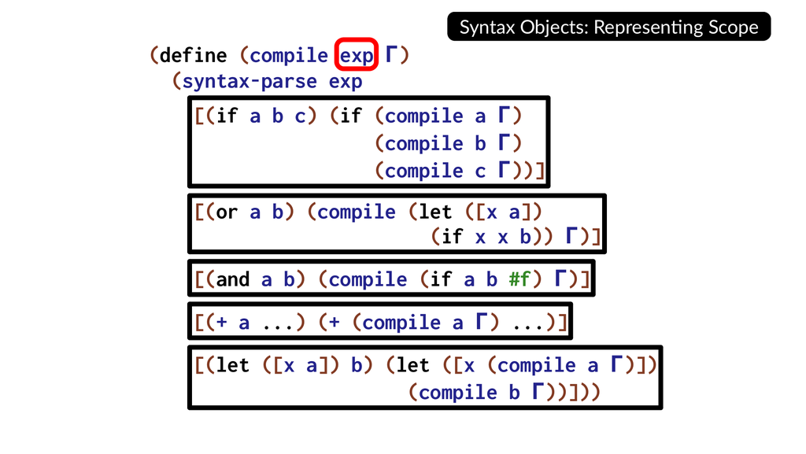

幻灯片 24：传入每个转换分支的数据结构Slide 24: The data structure passed to each transformation case

**幻灯片文字 / Slide text**

```
Syntax Objects: Representing Scope
(define (compile exp Γ)
  (syntax-parse exp
  [(if a b c) (if (compile a Γ)
(compile b Γ)
(compile c Γ))]
[(or a b) (compile (let ([x a])
  (if x x b)) Γ)]
[(and a b) (compile (if a b #f) Γ)]
[(+ a ...) (+ (compile a Γ) ...)]
[(let ([x a]) b) (let ([x (compile a Γ)])
  (compile b Γ))]))
```

总之，那是很棒的工作。对，好。现在我们来谈谈这个参数：它的类型是什么？它是什么数据结构？因为每一个分支都会使用这个参数，对吧？每一个分支都会接收一个这样的东西，并且预期产生一个这样的东西。因此，这个数据结构中有一些值得处理的有趣问题。

Um but anyway that's that's good stuff. Yeah. Okay. So let's talk about let's talk about this argument now but like what's its type? What's the data structure? Because this argument is going to be used by each of these cases, right? Each one's going to get one of those things in and expected to produce one of those things out. So there's some interesting stuff to handle in that data structure.

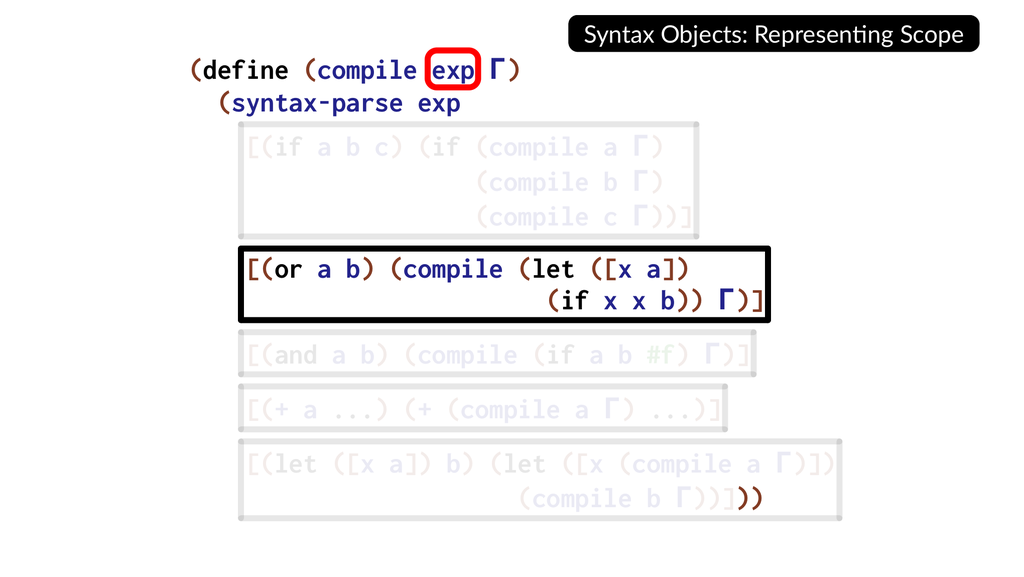

幻灯片 25：or 的展开引入局部变量Slide 25: Expanding or introduces a local variable

**幻灯片文字 / Slide text**

```
Syntax Objects: Representing Scope
(define (compile exp Γ)
  (syntax-parse exp
  [(if a b c) (if (compile a Γ)
(compile b Γ)
(compile c Γ))]
[(or a b) (compile (let ([x a])
  (if x x b)) Γ)]
[(and a b) (compile (if a b #f) Γ)]
[(+ a ...) (+ (compile a Γ) ...)]
[(let ([x a]) b) (let ([x (compile a Γ)])
  (compile b Γ))]))
```

请大家注意这个例子。or 宏是一个经典的宏例子，原因马上就会明白。我们所处的语言采用真值语义，也就是说，任何不是 false 的值，都会使 if 表达式走 then 分支；而我们想要一个短路求值的 or。如果你的语言是这样的，那么你就别无选择，必须引入一个局部变量。

And let me focus your attention on this case. So this is a the or macro is like a classic macro for reasons that will become clear in just a moment here. So we're in a truthy language. So everything that's not false, you know, takes the then branch in an if expression and we want a shortcircuiting or. So if that's what your language has, then you have no choice but to introduce a local variable.

而且，你还别无选择，必须让这个局部变量包围其中一个子表达式。好，我相信大家的警报都响起来了，对吧？这里的 A 和 B 都是任意的表达式，而我现在竟然在 B 外面套了一个 x。糟了，对吧？所以这里存在问题。当然，你也可以说，没关系，反正这是任意的 Racket 代码，在这里生成一个新鲜名称不就行了吗？

And furthermore, you have no choice but to put that local variable around one of the sub expressions. Okay, which I'm sure red flags are going off for all. Right? These are arbitrary expressions A and B here. And now I just stuck an X around B. Oops. Right? So there's some issues there. Okay, you could say fine, no problem. Just this is arbitrary racket code. Just generate a fresh name here, right?

要处理这种情况，确实只需要这么做。事实上，Clojure 就有这样的宏系统：你只要在标识符末尾加一个 #，Clojure 看到 #，就会替你生成那个新鲜名称。不过，这种做法有一个问题。首先，从软件工程的角度看，这个默认行为是不对的。

That's that's all you really need to do to handle this situation. In fact, Closure has a macro system where you just put like a hash on the end of the identifier and then Closure will go generate that fresh name for you when it sees a hash. But there's a problem with this way of doing things. First of all, from a software engineering point of view, it's the wrong default.

你不应该为了避免名称捕获而做特殊处理；你应该在想要名称捕获时才做特殊处理，对吧？大多数时候，你并不希望发生名称捕获。因此，你应该只管像这样编写代码，然后系统就能正确处理。这是第一点。第二点稍微更技术性一些：你可以编写一个宏，让它展开成另一个宏。

You shouldn't do something special to avoid capture. you should do something special to get capture, right? So you want capture, you don't want capture most of the time. So you want to just write stuff like this and have the right thing happen. That's one. The second point is a little more technical. There's this you can write a macro that expands into another macro.

当你编写这样的宏时，要弄清楚究竟应该在什么时候生成新鲜名称，就真的不简单了。因为，如果宏要展开成另一个宏，就会有第一次展开的时刻；那个时刻也许适合生成新鲜名称。另外，还有第二个宏执行那个生成出来的展开操作的时刻。

And when you write such macros, it becomes really non trivial to understand when you should be doing the generation of the fresh names. Because if the macro is going to expand into another macro, there's the moment at which it does the first expansion, which is maybe the right time to generate the fresh name. And there's the moment at which it's doing that generated expansion in the second one.

也许那才是生成新鲜名称的正确时刻。也许两个时刻都需要，你看，事情会变得复杂。因此，你真正需要的是一种数据结构，替你管理所有名称生成的事情。只要你不希望发生名称捕获，就不需要为此做任何事情。好，这就是这个数据结构要解决的问题。

Maybe that's the right moment to do the fresh name. Or maybe both are, you know, it's it gets complex. So what you really want is something a data structure that just manages all the name generation and and you don't have to do anything about it as long as you don't want capture. Okay. So that's what this that's what this data structure is going to be about that. All right.

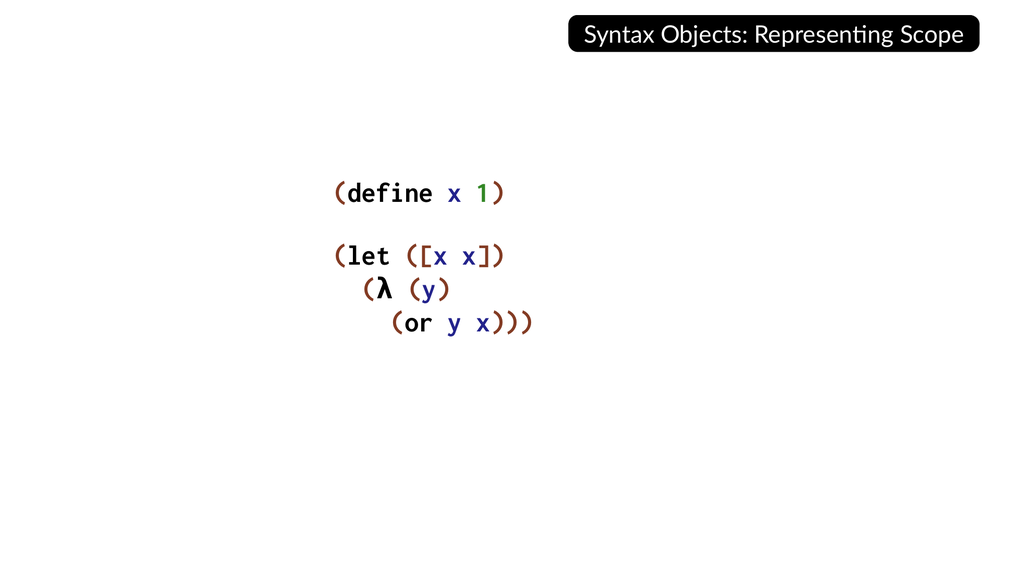

幻灯片 26：语法对象具有清晰可见的树结构Slide 26: Syntax objects have visible tree structure

**幻灯片文字 / Slide text**

```
Syntax Objects: Representing Scope
(define x 1)
(let ([x x])
  (λ (y)
  (or y x)))
```

为了说明这一点，我需要花一点时间解释这个数据结构。这里有两个例子，它们叫作语法对象。这是两个语法对象的例子。Racket 有括号，从某种意义上说，正是因为宏系统、因为这些语法对象，才有这些括号。不是因为我们喜欢括号——虽然我们确实喜欢。

So in order to explain it I have to it takes a few moments to explain this data structure. So here's two example they're called syntax objects here. Here are two example syntax objects and racket has parenthesis and it's because of the macro system and because of these syntax objects that the parentheses are there in some sense. It's not because we love parenthesis although we do.

它们真正的作用，是帮助你看清楚宏转换中发生了什么。看到这里，你能看出这是 x 的定义，同时也能看出一棵树。你看到括号，就知道它是一个内部节点。然后你看到它有三个子节点，而这三个子节点没有括号，因此它们都是叶节点。所以你能看出这是一棵树，对吧？

Uh it's really to help you see what's going on in your macro transformations. So when you look at this, you can see a definition of X, but you can also see a tree. So you see parenthesis, therefore it's an interior node. Then you see it has three children and these three children do not have parentheses, therefore they're leaf nodes. So you can see this is a tree, right?

语法和树之间的对应关系非常清晰，而语法对象里包含的就是这样的树。第二个例子也是一样，同样是一对括号，里面有三个东西，因此它是一个有三个子节点的内部节点。和前面一样，第一个子节点是叶节点。但这里的第二个子节点不是叶节点，里面还有其他内容。

And the sort of mapping between the syntax and the trees are very clear and that's the trees that the syntax objects are going to have. So the second one is the same thing. It's also a pair of parenthesis with three things inside. So therefore, it's an interior node with three children. And like here, the first child is a leaf. But here, the second child is not a leaf. It's got, you know, some more stuff.

## 色彩层级Chromatic Hierarchy

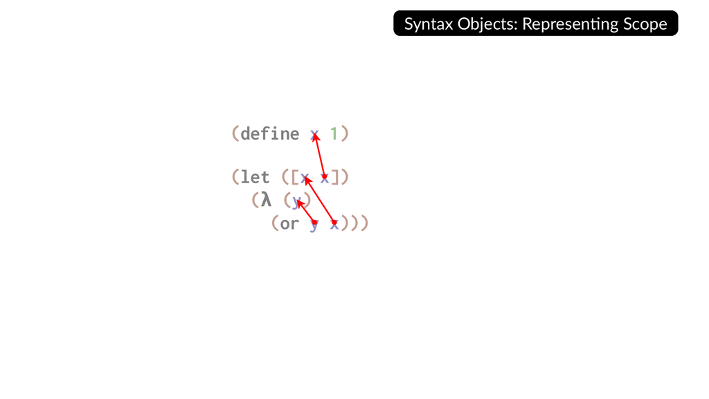

幻灯片 27：绑定箭头表达词法作用域Slide 27: Binding arrows express lexical scope

**幻灯片文字 / Slide text**

```
Syntax Objects: Representing Scope
(define x 1)
(let ([x x])
  (λ (y)
  (or y x)))
```

方括号和圆括号是一样的，这里只是另一个内部节点。好。作用域，我们来谈作用域。如果你和我一样，学习时应该听过这样的说法：对编译器或编程语言的实现来说，变量名并不真正重要，重要的是这些箭头。名字只是给人看的。

And the square brackets are the same thing as parentheses. It's just, it's just another interior node here. Okay. Um, so scope, let's talk scope. So, if you're like me, you were taught variable names are not really relevant for the compiler or implementing your programming language. What's relevant are the arrows. The names are just there for the humans.

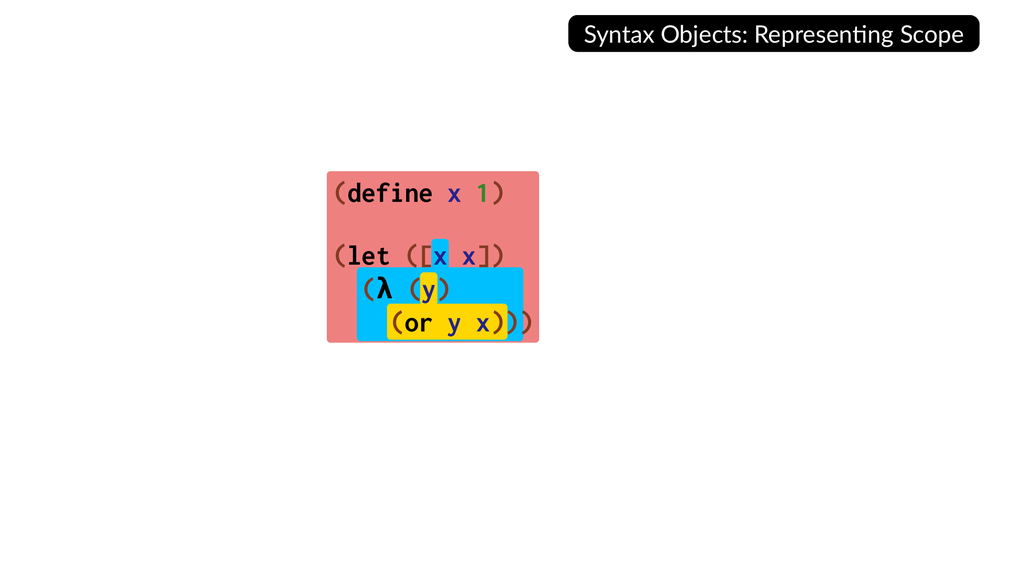

幻灯片 28：用区域表示作用域Slide 28: Representing scopes as regions

**幻灯片文字 / Slide text**

```
Syntax Objects: Representing Scope
(define x 1)
(let ([x x])
  (λ (y)
  (or y x)))
```

我们真正关心的是，这个箭头在某种意义上才是作用域的本质。好，语法对象并不会用这样的箭头来表示作用域，而是采用另一种方式，也就是区域。我们将从这些区域中恢复箭头。好，这就是我们要做的事情。

And what we really care about is that these this arrow is somehow really the essence of what's happening with scope. Okay, the syntax objects do not represent scope using arrows like this. Instead, they represent them another way, regions, and you can we're going to recover the arrows from the regions. Okay, so that's the game.

我会解释这些区域是如何工作的，然后展示怎样利用这些区域恢复箭头，也就是那些真正体现作用域本质的连接。我们把这些区域叫作作用域，因为这就像……好，这里是红色作用域，它里面是蓝色作用域，再里面是黄色作用域。

I'm going to explain the how these regions work and then show you how you recover the arrows, which are really the essence of scope these these links using the regions. Okay, so we call the region scopes because that's like Okay, so this there's the red scope and then inside that there's the blue scope and then inside that there's the yellow scope.

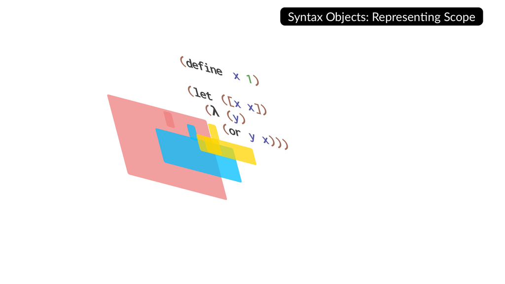

幻灯片 29：嵌套区域与三维层次Slide 29: Nested regions and their three-dimensional layering

**幻灯片文字 / Slide text**

```
Syntax Objects: Representing Scope
(define x 1)

(let ([x x])
  (λ (y)
  (or y x)))
```

你可以看出，这个蓝色的 let 操作符并不是递归的，因为这里并没有蓝色，对吧？因此，你能看出它的作用域结构。不过，这张图有点令人困惑，因为它有些像三维图：红色的部分在蓝色部分后面，蓝色部分又在黄色部分后面。

And you can see that this the blue this let operator is not a recursive thing because it's not blue here. Right? So you can see the kind of scope structure of this. Um this picture is a little bit confusing though because it's sort of a three dimensional picture, right? There's like the red thing is kind of behind the blue thing is behind the yellow thing.

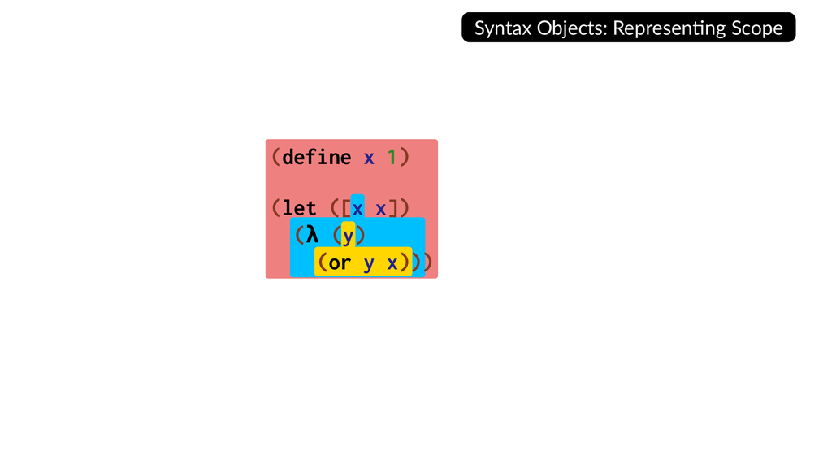

**幻灯片文字 / Slide text**

```
Syntax Objects: Representing Scope
(define x 1)
(let ([x x])
  (λ (y)
  (or y x)))
```

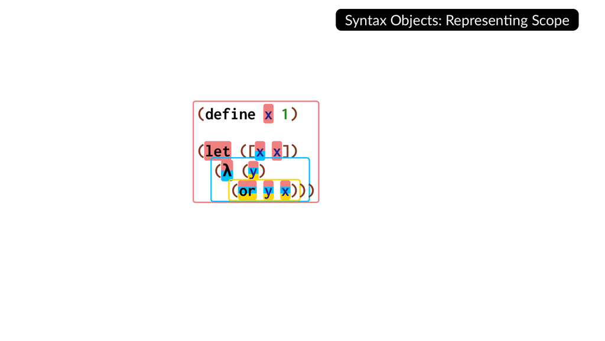

幻灯片 31：在语法节点旁标注作用域集合Slide 31: Attaching scope sets to syntax nodes

**幻灯片文字 / Slide text**

```
Syntax Objects: Representing Scope
(define x 1)
(let ([x x])
  (λ (y)
  (or y x)))
```

所以，我不再这样画，而是收集每一个叶节点所处的全部作用域，形成一个集合。现在是鸡尾酒时间。然后把这些集合写在叶节点上。好，我暂时保留这些方框，只是让大家能看清各部分从哪里来。不过，这些方框本身并不重要。好，让我把它们擦掉。

So instead of drawing it like that, I'm going to collect all the entire set of scopes that each leaf node is in. It's a cocktail hour. And and put them write them on the leaf nodes. Okay. And I've left the boxes here for now just so you can sort of see where things come from. Um but the boxes are not they're not really relevant. Okay. And let me erase them.

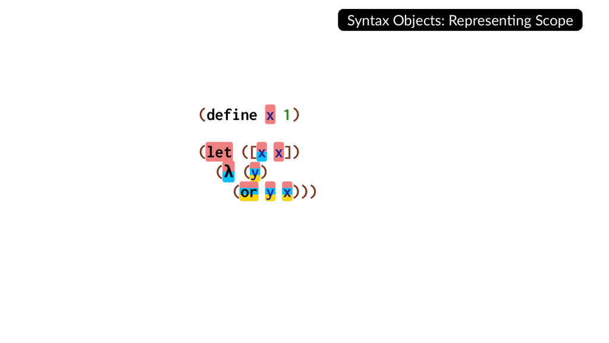

幻灯片 32：去掉区域框，仅保留节点上的集合Slide 32: Removing region boxes and keeping the scope sets

**幻灯片文字 / Slide text**

```
Syntax Objects: Representing Scope
(define x 1)
(let ([x x])
  (λ (y)
  (or y x)))
```

这些就是各个叶节点所处的作用域集合。实际上，每一个子表达式，甚至内部节点，都关联着一个作用域集合。只是把它们都画出来会让图太乱，所以我只在叶节点上画出来。好，这就是这个数据结构所包含的内容。

So these are the set of scopes that each leaf node is in and actually every subp expression even the interior nodes have sets of scopes associated with them. It just it's clutter in the diagram. So I'm just going to draw them on the leaf nodes. Okay. So this is what the data structure has.

## IR 中的绑定出现位置Binding Occurrences in the IR

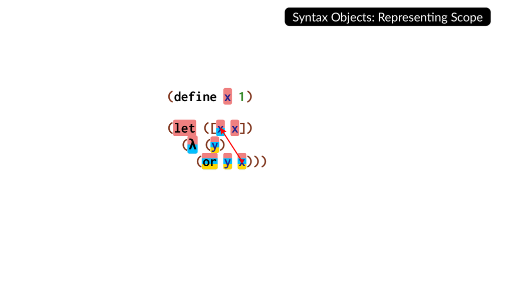

幻灯片 33：从集合信息恢复绑定关系Slide 33: Recovering binding relationships from scope sets

**幻灯片文字 / Slide text**

```
Syntax Objects: Representing Scope
(define x 1)
(let ([x x])
  (λ (y)
  (or y x)))
```

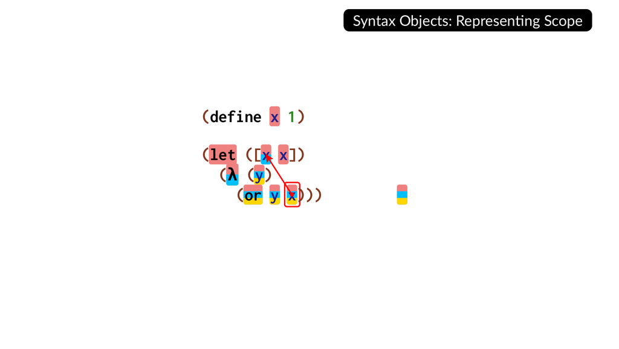

幻灯片 34：查看一个引用所携带的作用域集合Slide 34: Inspecting the scope set of a reference

**幻灯片文字 / Slide text**

```
Syntax Objects: Representing Scope
x
(define x 1)
(let ([x x])
  (λ (y)
  (or y x)))
```

我们来看这个 x——哦，来看这里的箭头。怎样根据数据结构中的这些信息恢复这个箭头呢？下面这个 x 的作用域集合是红、蓝、黄，而我们想要的绑定者的作用域集合是红、蓝。这就是我们要使用的基本规则。

So if we look at this X oh so if we look at this arrow here, how can we recover this arrow from the in this information in the data structure? Well, this X down here is in the set of scopes red, blue, yellow. And the binder that we want is in the set of scopes red blue. So that's the basic rule we're going to use.

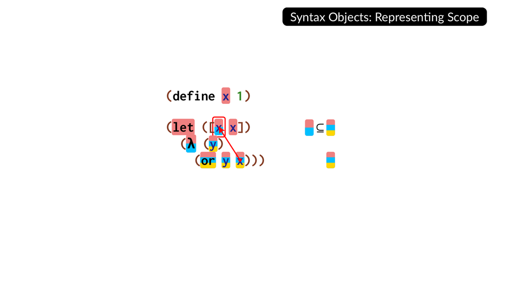

幻灯片 35：候选绑定位置的集合必须是引用集合的子集Slide 35: A candidate binding's scopes must be a subset of the reference's scopes

**幻灯片文字 / Slide text**

```
Syntax Objects: Representing Scope
x
(define x 1)
(let ([x x])
  (λ (y)
  (or y x)))
 ⊆
```

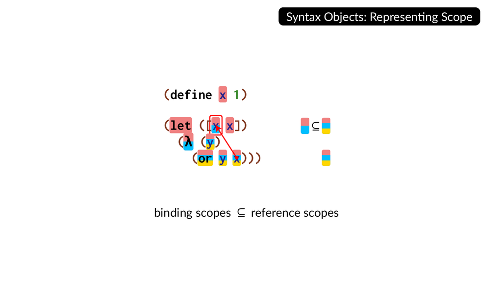

幻灯片 36：绑定规则：binding scopes ⊆ reference scopesSlide 36: Binding rule: binding scopes ⊆ reference scopes

**幻灯片文字 / Slide text**

```
Syntax Objects: Representing Scope
x
(define x 1)
(let ([x x])
  (λ (y)
  (or y x)))
 ⊆
binding scopes  ⊆  reference scopes
```

如果绑定者上的作用域集合，是引用上的作用域集合的子集，那么它就绑定这个引用。好。哦，抱歉，对，还有两件事要说。你怎么知道它是绑定者？好，其实你不必关心，可以选一个作用域集合为子集的。不过，它必须处于绑定位置。在这场报告里，你可以认为绑定者总是在外层，以嵌套的方式存在。

If the set of scopes on the binder is a subset of the set of scopes on the reference, then it binds. Okay. Oh, okay. Sorry. Right. Two other things to say. You know there you know it's a binder tech. Okay. You don't actually need to care. you can just take one that's the that's a subset. It's it has to be in a binding position. Um and for this talk it's okay if it's always outside nested.

对，对，这是在 IR 中。因此，只有得到 IR 之后，我们才需要做这件事。其实还有一点内容，我们马上会讲到。不过，是的，你需要知道它处于绑定位置。因此，要进行这一步、确定这个关系，你需要了解 IR 中的构造。

Yeah. Yeah. This this is in the IR. So we're going to be able we only need to do this once we have the IR. Okay. Actually there's a little bit more which we're going to get to here in just a moment. Um but yeah, you need to know it's in a binding position. So, you need to know what's in the IR in order to do this to determine this thing.

至于引用，你不需要知道。好，这里还有更多可说的，但会让人困惑。我们暂时先接受这一点。因为宏是任意的，就像一个任意的函数一样，所以它能做一些奇怪的事情，比如把这个 x 复制成一个绑定位置和一个……因此，这里也可能发生一些奇怪的情况。

Um, the reference you just you don't you don't need to know. Okay, there's more to say there, but it's confusing. Okay, but just let's take this as truth for the moment. Okay, because macros are arbitrary, you know, it's like an arbitrary function. So, it can do weird things like duplicate this x into a binding and a so there's weird things that can also happen here.

不过，现在我们先说，因为它处于 IR 中，我们知道它是一个绑定出现位置，而这里就是 IR 中用于绑定的位置。对，对，对。好，下一张幻灯片就会讲到。对，你刚才是想说这个吗？或者说，一个宏会规定第一个变量处于绑定位置。对，对，对，对。那么你怎么知道呢？你刚才说的是这一点。

But for now, let's just say you we know it's a binding occurrence because it's in the IR. And this is the this is a place where binding occurrences are in the IR. Yeah. Yeah. Yeah. Okay. That's the next slide. Yes. Is that what you were going to say? Or is a macro say the first variable be a binding position. Yeah. Yeah. Yeah. Yeah. Yeah. So how would you know? You said this.

## 展开器的规则：IR 形式中的绑定作用域The Expander's Rule: Binding Scopes in IR Form

所以，我们不知道——对，没错。我们实际上并不知道这个是……我们之所以知道会发生这种情况，只是因为我们考虑了一点 or 会做什么的信息。也就是说，它最终会把这个放到完全展开的 IR 中的引用位置上。哦，所以，如果不知道 or 会做什么，我们就无法这么判断。对，没错。

So we don't we don't That's right. We don't actually know that this is we only know this is going to happen because we're taking a little bit of information up into account about what ore is going to do. Namely that it's going to put this in a in a eventually in the fully IR in a reference position. Oh, so we couldn't do this without knowing what or that's right. That's right. Yeah.

所以，你必须按这个过程来做：先放入作用域，再解析这些箭头。箭头的解析只能在 IR 中进行，而放入作用域、从而使解析得到正确结果的过程，则发生在宏展开期间。好，对，对，对，很好。不，不，我很乐意讨论。所以，我还没有说作用域是怎样放进去的。

So you have to do this after the this process of putting the scopes in and then resolving the arrows. Resolving of the arrows has to happen only in the IR and the process of putting the scopes in. And so the right resolution happens is through the macro expansion process. Okay. Yeah. Yeah. Yeah. Good. No, no, I'm very happy to. So So I haven't said how the scopes get put in yet.

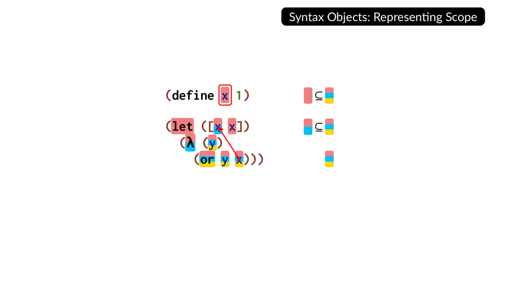

幻灯片 37：另一个候选绑定位置也可能满足子集条件Slide 37: Another candidate binding may also satisfy the subset condition

**幻灯片文字 / Slide text**

```
Syntax Objects: Representing Scope
x
(define x 1)
(let ([x x])
  (λ (y)
  (or y x)))
 ⊆
 ⊆
```

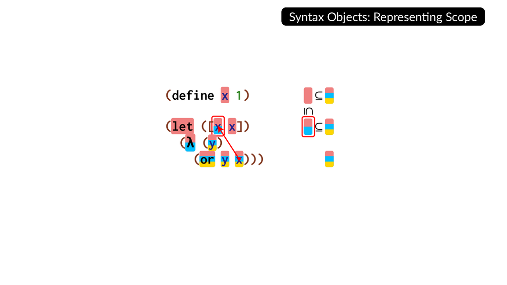

幻灯片 38：比较多个候选的作用域集合Slide 38: Comparing the scope sets of candidate bindings

**幻灯片文字 / Slide text**

```
Syntax Objects: Representing Scope
x
(define x 1)
(let ([x x])
  (λ (y)
  (or y x)))
 ⊆
 ⊆
⊆
```

几分钟后我会解释。好，好，很好。那么，我们来回答这个问题：等一下，红色也是红、蓝、黄的子集啊，那它怎么办？红色也是红、蓝的子集。因此，让我稍微完善一下规则：我们使用处于绑定位置的那个最大的子集。

I'll say that in a few minutes. Okay. Okay. Good. All right. So let's get this question like wait a minute. Red is a subset of red, blue, yellow. Okay. What about that one? Um well red is a subset of red blue. So let me refine the rule just a little bit which is we use the subset we use the largest subset that's in a binary position.

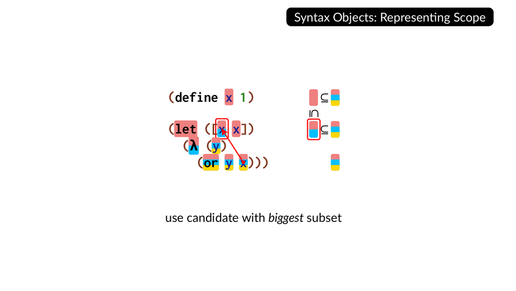

幻灯片 39：选择作用域集合最大的候选绑定Slide 39: Use the candidate with the biggest subset

**幻灯片文字 / Slide text**

```
Syntax Objects: Representing Scope
x
(define x 1)
(let ([x x])
  (λ (y)
  (or y x)))
 ⊆
 ⊆
⊆
use candidate with biggest subset
```

相对于这个引用的集合，这一个比另一个是更大的子集，因此箭头就指向它。好，这回答了你的问题吗？对，好。现在我们来谈它是怎样……对。

So this one is a larger subset than this one of the reference. So therefore it's the one that gets the arrow. Okay. Does that answers your question? Yeah. Okay. Um and now let's talk about how this Yeah.

也就是说，你必须在某个地方绑定它，但那些节点可能还没有成为相应的形式。展开算法的工作方式是，你总是从外向内处理，因此总会有一道边界，边界里面是尚未展开的代码，而外面已经全部是 IR 代码。对，你就是这样知道的。也正是在这个时刻，展开器把作用域加上去。

Which is like you have to bind it somewhere while probably the nodes are not in form already that so the way the expansion algorithm happens you're always working from the outside in so you always have some frontier kind of that's unexpanded code and everything outside is IR code yeah so that's how you know so yeah and that's exactly so that's the moment exactly when the scopes get put on by the expander.

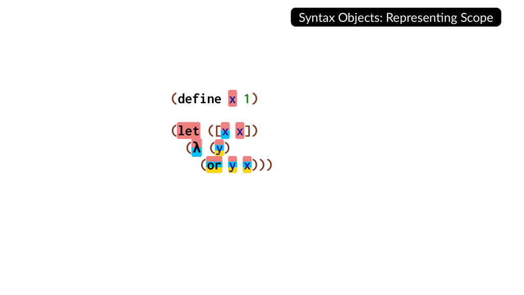

幻灯片 40：展开器在处理绑定形式时添加作用域Slide 40: The expander adds scopes when processing binding forms

**幻灯片文字 / Slide text**

```
Syntax Objects: Representing Scope
(define x 1)
(let ([x x])
  (λ (y)
  (or y x)))
```

所以，当展开器看到一个 IR 形式，而且这个 IR 形式引入了变量绑定时，它就生成一个新作用域，把这个作用域加到绑定者上。也就是说，对 define、对 let 的绑定位置加上这个作用域，然后也把它加到树中允许出现相应引用的那一部分。对于 let，就会加到下面这一整片区域。

So when the expander sees an IR form and that IR form introduces a variable binding, it generates a new scope puts that scope on the binder. So it puts the scope on the define on the let and then it also puts the scope on the sub on the part of the tree where the references are allowed to be. So for a let it would put it everywhere down here.

对于 define，它会像这样加到所有地方。这是第一种情况。刚才介绍展开器算法时，我没有展示这一点，因为那时我们还没有准备好讨论语法对象。不过，展开器看到完全展开形式时，还会把作用域加上去。这就是这里所有颜色的实际来源。另外，还有一个必须添加作用域的时刻，就是执行转换的时候。

For the define, it's going to put it everywhere like that. Okay, that's one. So I didn't show that in the expander algorithm because we weren't ready yet to talk about the syntax objects. But in addition when it sees a fully expanded form, it puts scopes on to and that's how we get actually all the colors that are here. Now there's one other time it has to put scopes on and that's when it does a transformation.

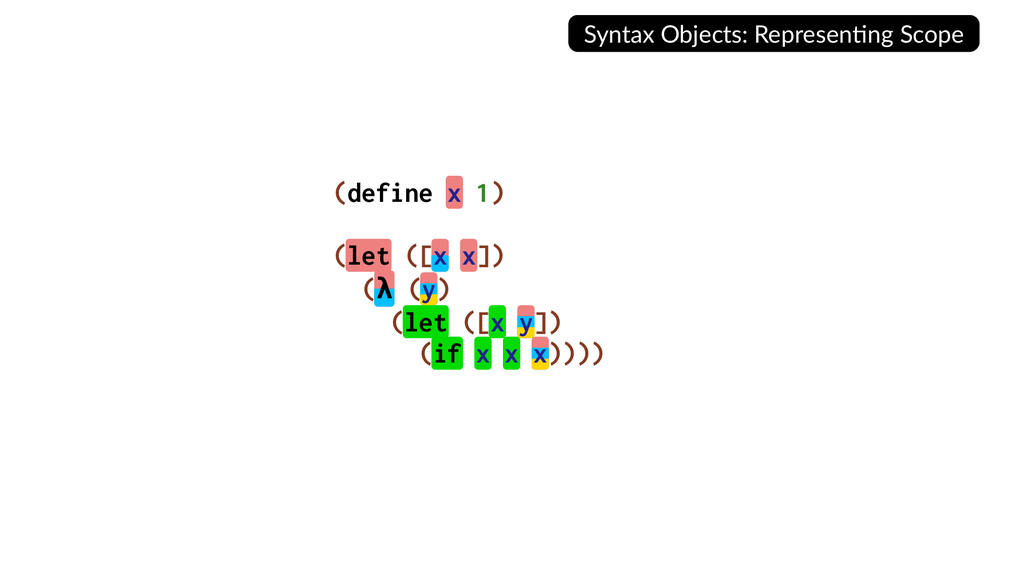

幻灯片 41：宏新引入的语法获得一个新的绿色作用域Slide 41: New syntax introduced by a macro receives a fresh green scope

**幻灯片文字 / Slide text**

```
Syntax Objects: Representing Scope
(define x 1)
(let ([x x])
  (λ (y)
  (let ([x y])
  (if x x x))))
```

所以，作用域——这个 or 宏就是我们前面看到的那个。它会做这样的事情。好，这就是之前那个 let。展开器遵循的规则是：在这一步展开的输出中，凡是输入里没有的东西，都会得到一个新作用域。规则就是这样。因此，这里的所有绿色部分都是这么来的。

So the scopes so this or macro it's the same one we saw before. This this is what it's going to do. Okay. So this is the let that we saw before and the rule that the expander follows is everything that's in the output of the expander output of that expansion step that was not in the input gets a fresh scope. That's the rule. So that's all the green stuff here.

## 在数据结构中改变作用域是一个常见挑战，但可以用高效算法来处理Changing scope in data structures is a common challenge, but it's manageable with efficient algorithms

所以，y 和 x 在输入里已经有了，它们不会得到新作用域。但这个 let、这三个 x 以及这个 if 都不在输入里，因此它们会得到新作用域。好，好。这里面藏着一个数据结构问题，对吧？

So the y and the x were in the input so they don't get the new scope. But this let this these three x's and this if were not in the input therefore they get the new scope. Okay. Okay, so there's a data structure problem hand hiding inside here, right?

我们需要进行这样的操作：给一整棵子树加上一个作用域；同时还需要做这种比较差异的操作。关于实际的数据结构，还有更多内容可讲，但我们不会深入。暂且请相信我，这些操作实际上都可以做到常数时间。你可以直接对这个数据结构执行这两种操作。对。

We have to do this we want to do we want to do this operation of you know put a scope on an entire subree and we want to do this kind of diffing operation thing. So there's more to say about the actual data structure that we're not going to get into but just for believe me that there are these are effectively constant time operations. You can just do those two things to this data structure. Yeah.

## 宏编程中的指针同一性与复杂性Pointer Identity vs. Complexity in Macro Programming

这些我不熟悉，抱歉。也许稍后你可以帮我了解一下。好，谢谢。对，对，对。就像……所以你可以……不，不，不，这个 x 并不在输入里。如果他们把这个 x 复制过来放在这里，那么是的，你就不会加上绿色。但他们创建了一个新的 x，再把这个新 x 放到这里、这里和这里。所以它才得到了绿色。

I don't know these. I'm sorry. So, let's maybe you can help me later. Okay. Thank you. Yeah. Yeah. Yeah. It's like So, so you can No, no, no. This this X was not in the input. If they kind of copied this X over and put it here, then yes, you wouldn't put green. But they made a new X and they put that and that and that new So that's why it got a green.

它是一个新的 x，一个不同的 x。这里有一种很有意思、很复杂的表示方法。你问的是一个数据结构和算法问题，对应的就是刚才那五篇论文中的最后一篇。实际上，第三篇论文还给出了另一种版本，使用了更复杂的数据结构，效果没有那么好；或者更准确地说，效果同样好，只是更复杂。

It's a new X. It's a different X. There's an interesting complex representation in you know it's a data structure and algorithm question you're asking me and that was the last paper in that list of five papers. Um, and actually the third paper had a different version of it that used a more complex data structure that didn't work as well or well actually worked as well but it was more complex.

所以，要完整解释其中发生了什么，光这件事就足够讲好几场报告了。不过，只要你获得这样的直觉就够了：如果我在转换器里塞进一些新代码，它就会得到这个作用域；如果我只是从输入里拿起某个东西，再放到输出里，它就不会得到新作用域。

So that's like multiple talks in its own to fully explain what's going on. But for like if you get the intuition of like if I stuck some new code in my transformer that's going to get the scope and if I just picked up something from my input and dropped in my output that's not going to get the new scope.

如果你想在那个层次上理解，可以把它想成指针同一性之类的东西，这样就够了。这就是我们需要的全部内容，也是你成为现代宏程序员所需知道的全部内容。如果你还想更进一步，成为现代宏研究者，那么，好吧，去读这些论文。对，没错。你可以把它想成……对。

You can think about it like pointer identity or something like that if you want to think about it that at that level. then we're good. Okay, that's all we need for that's all you need to become a modern macro programmer. And if you want to go beyond that to become a modern macro researcher, well, okay, read the papers. Yeah. Yes. Yeah, you can think of it like like Yeah.

或者，就把它看作传进来的那个值的某种指针同一性之类的东西。不，不，它会查看输入和输出，实际上是在比较输入和输出，而且做的是更复杂的事情。对，对，我们先不要深入。我的意思是，你已经明白这些应该是绿色，而那些不应该是绿色。

Or or like just think of it like pointer identity of the of the value that came in somehow or something like that. No, no, it looks at the input and output. It's actually comparing the inputs and outputs and it's doing something more complex. And yeah. Yeah. Let's not let's not let's not go. I mean, you get you get that these are supposed to be green and these are not.

## 以归纳方式改变作用域Changing Scope Inductively

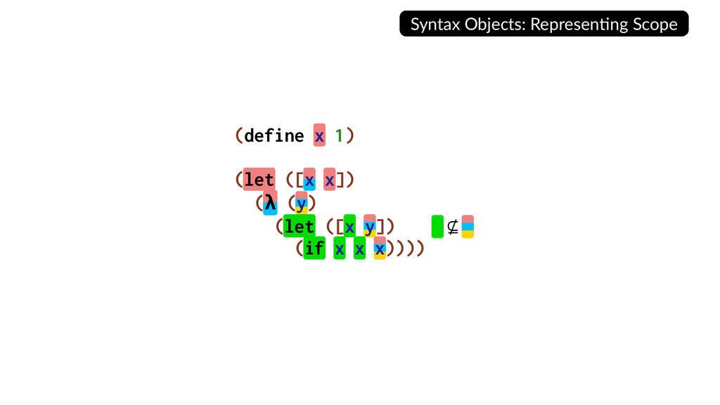

幻灯片 42：绿色不在原引用的集合中，因此不会发生捕获Slide 42: The green scope is absent from the original reference, preventing capture

**幻灯片文字 / Slide text**

```
Syntax Objects: Representing Scope
(define x 1)
(let ([x x])
  (λ (y)
  (let ([x y])
  (if x x x))))
 ⊈
```

那么，暂时就说到这里。好。关键在于，它会选择一种新的颜色，加到新引入的东西上。所以，当你加入一些新代码时，就会得到一种新的颜色。这就是这张幻灯片的全部要点。对。而我们之所以这么做，是因为，看，这里发生了变化：绿色并不是红、蓝、黄的子集。

So, like let's leave it there for now. Okay. That's that's essential. That's essential that there that it picks a fresh color to put on the new stuff. So when you stick some new code in, you're going to get a fresh color. That's the whole point of the slide. Yeah. And and the reason we do that is because look, okay, was like a change here. Green is not a subset of red, blue, yellow.

因此，我们就不会发生名称捕获，对吧？这差不多就是全部目的。所以，即使有人一不小心、运气不好地选中了同一个名字，这条箭头仍然能够保留。这就是作用域被管理的方式，也是系统替你正确管理绑定结构的方式。好，下面以归纳的方式给出实际的数据结构。

So therefore, we don't capture, right? That's kind of the whole point. So this arrow is still preserved even though somebody accidentally unluckily chose a name, right? And this is how the scopes are managed. Uh this is how the the binding structure is managed for you correctly. Okay. So here's the here's the actual data structure kind of inductively.

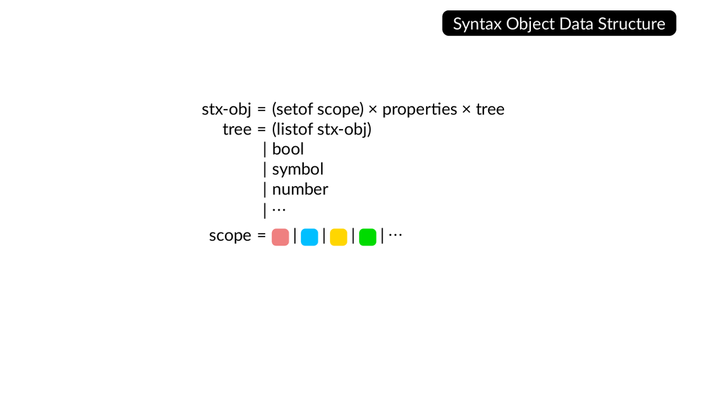

幻灯片 43：语法对象：作用域集合、属性与树Slide 43: Syntax objects: scope set, properties, and tree

**幻灯片文字 / Slide text**

```
Syntax Object Data Structure
stx-obj = (setof scope) × properties × tree
tree = (listof stx-obj)
| bool
| symbol
| number
| ⋯
scope =
 |
 |
 |
 | ⋯
```

我不会过多讨论这个，不过有一点要说：语法对象是一个三元组，由作用域集合、树结构以及这些属性组成。编写编译器时，如果能为树里的每个子表达式附带一个键值存储，会非常方便。好，这里就提供了这样的东西。

Um I don't want to I'm not going to talk about this too much but there's a one thing to talk about is syntax objects are a triple of the set of scopes and then the tree structure and then this properties. So it's very convenient to be able to kind of have a key value store stuck with every subp expression inside a tree when you're writing a compiler. Okay. So that's there in here.

因此，每个子表达式的源代码位置信息之类的东西都会附在这里。对，它是一个集合。是的，是的，真的是集合。我写的是红、蓝、黄，但蓝、红、黄也是一样的。它是集合，所以没有顺序。在实现里的数据结构中，它确确实实就是一个集合。

So it's got things like source location information for every subp expression stuck here. Yeah, it's a set. Yes. Yes, they're really sets. Yes. So I wrote the red, blue, yellow, but it, you know, blue, red, yellow is the same thing. It's a set. So there is no order. Like it's really a set in the data structure in the implementation.

如果你那样做——我记得，有个比我更懂宏的人，曾经和提出作用域集合的人进行过一场很长、很精彩的讨论。我想是 Michael Ballantyne 和 Matthew Flatt，讨论能不能改用作用域列表，因为那样会改变某些东西，这里面确实有值得研究的内容。也许，我想，是的，好。那么，当然，直接操作这种归纳定义的数据结构会非常难受。

If you did, I think someone much smarter about macros than me had a nice long discussion with the person who worked out set of scopes. I think that was Michael Valentine with Matthew Flat and whether list of scopes could do a thing because it would change certain and like there's something there. Uh maybe I think yeah okay all right so of course working directly with this inductive data structure is terrible. Okay.

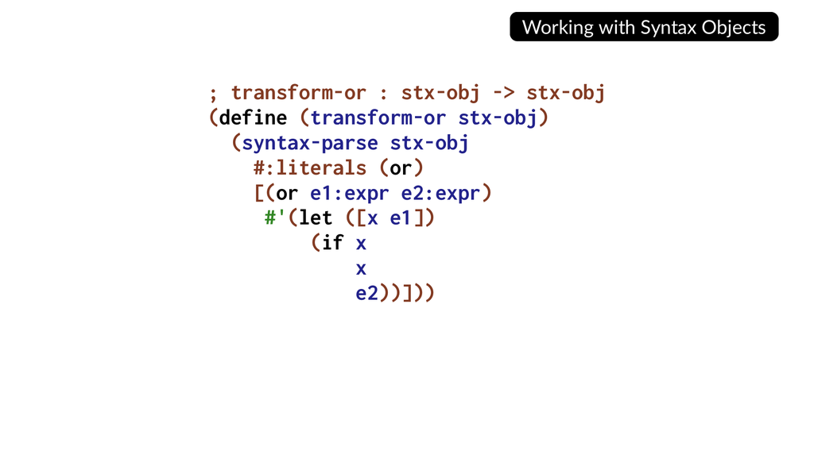

幻灯片 44：使用 syntax-parse 和语法模板实现 transform-orSlide 44: Implementing transform-or with syntax-parse and a syntax template

**幻灯片文字 / Slide text**

```
Working with Syntax Objects
; transform-or : stx-obj -> stx-obj
(define (transform-or stx-obj)
  (syntax-parse stx-obj
  #:literals (or)
  [(or e1:expr e2:expr)
#'(let ([x e1])
  (if x
x
e2))]))
```

所以，我们实际使用的是建立在它上面的两种更高层次的工具。一种类似模式匹配器，用来拆解它；另一种则用来构造新的数据结构。我来展示一个函数。这是一些 Racket 代码，我并不指望大家已经熟悉并能读懂它。

Um and instead what we work with is there are sort of two higher level things built on top of this one that's like a pattern matcher to pull it apart and the other one is a way to build new u new data structures. So let me show you a function and this is some racket code. So I'm not expecting you to be familiar with and read this code.

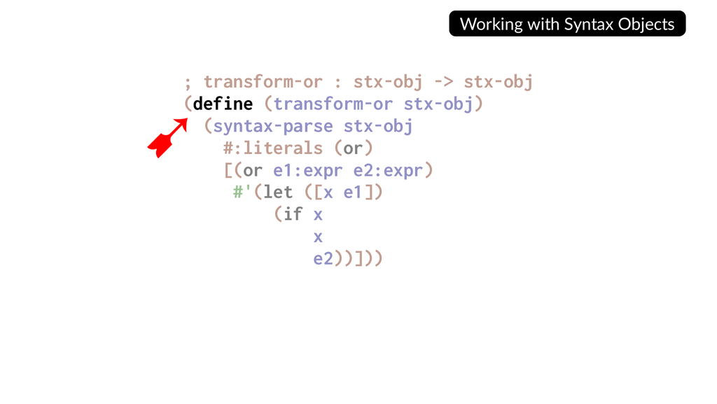

幻灯片 45：define：定义一个函数Slide 45: define: defining a function

**幻灯片文字 / Slide text**

```
Working with Syntax Objects
; transform-or : stx-obj -> stx-obj
(define (transform-or stx-obj)
  (syntax-parse stx-obj
  #:literals (or)
  [(or e1:expr e2:expr)
#'(let ([x e1])
  (if x
x
e2))]))
➹
define
```

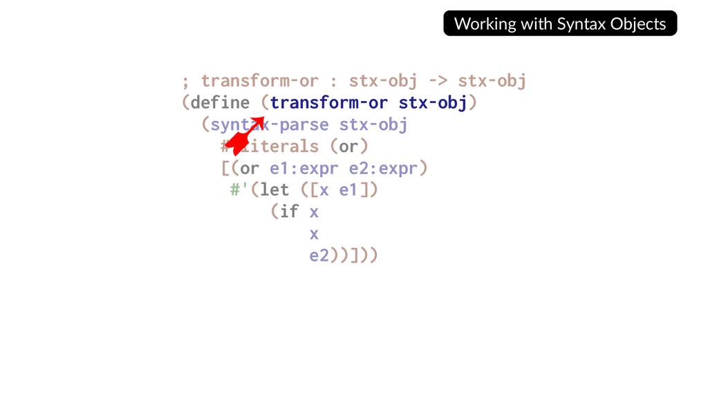

幻灯片 46：函数名 transform-or 与参数 stx-objSlide 46: The function name transform-or and its stx-obj argument

**幻灯片文字 / Slide text**

```
Working with Syntax Objects
; transform-or : stx-obj -> stx-obj
(define (transform-or stx-obj)
  (syntax-parse stx-obj
  #:literals (or)
  [(or e1:expr e2:expr)
#'(let ([x e1])
  (if x
x
e2))]))
➹
transform-or stx-obj
```

我们会一起慢慢地读一遍，好吗？然后再回头看，因为里面有一个有趣的要点，可以终于回答 Leonard 提出的、这场报告中最好的问题。好，我们来逐步看代码。define 表示我们正在定义一个函数。函数名是 transform-or。我们知道它是一个函数，是因为那里有那对括号。

So we're going to read it together kind of slowly. Okay? And then we'll look back at it again because it's got an interesting point to answer. Finally, Leonard's the best question in the talk. Okay. So let's just let's just go through the code. So define that means we're defining a function. Okay. The name of the function is transform or and we know it's a function because those pens were there.

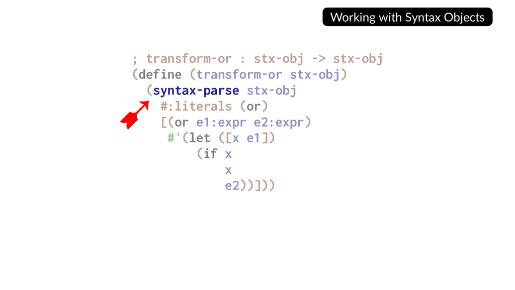

幻灯片 47：syntax-parse：解构输入语法Slide 47: syntax-parse: destructuring the input syntax

**幻灯片文字 / Slide text**

```
Working with Syntax Objects
; transform-or : stx-obj -> stx-obj
(define (transform-or stx-obj)
  (syntax-parse stx-obj
  #:literals (or)
  [(or e1:expr e2:expr)
#'(let ([x e1])
  (if x
x
e2))]))
➹
syntax-parse
```

我们知道这个函数有一个参数，因为这里写了一个东西。好，这不是减法。如果你要在 Racket 中写减法，还需要更多括号和空格。这里它只是名字中间的一部分。好，不要搞混。这个函数做的第一件事，是使用 syntax-parse，也就是这个模式匹配构造的名字。

And we know that the function has one argument because there's one thing written here. Uh, okay. This is not subtraction. If you want subtraction in Racket, you need more parentheses and spaces. Okay, this is just it's a it's in the middle of the name. All right, don't be confused. Okay, the first thing the function does is it uses syntax parse, which is the name of the pattern matching construct.

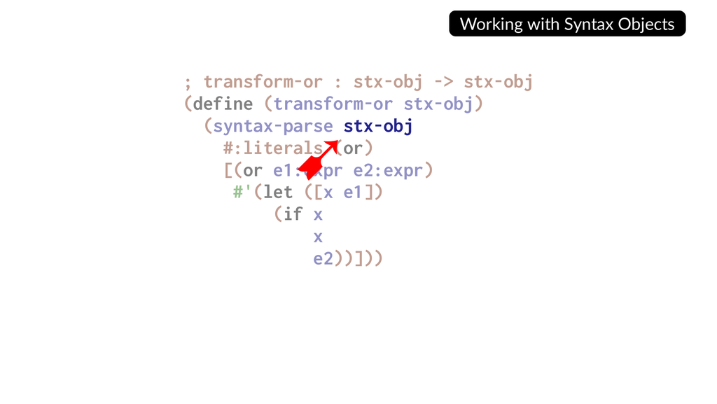

幻灯片 48：stx-obj 是要匹配的语法对象Slide 48: stx-obj is the syntax object to match

**幻灯片文字 / Slide text**

```
Working with Syntax Objects
; transform-or : stx-obj -> stx-obj
(define (transform-or stx-obj)
  (syntax-parse stx-obj
  #:literals (or)
  [(or e1:expr e2:expr)
#'(let ([x e1])
  (if x
x
e2))]))
➹
stx-obj
```

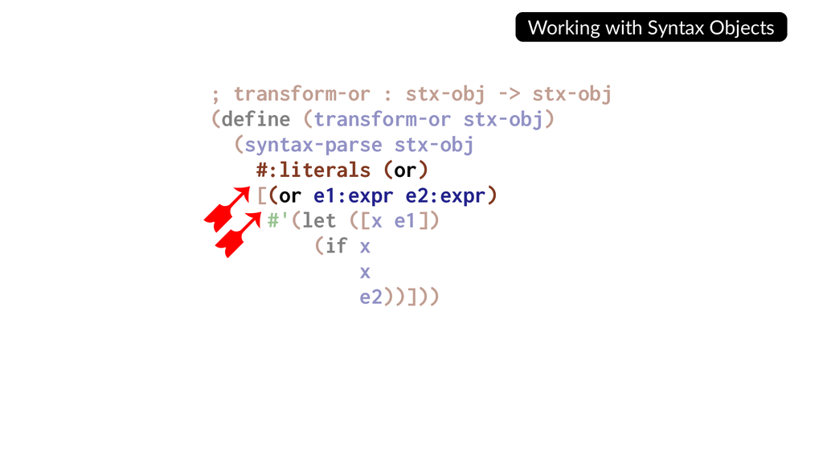

幻灯片 49：模式：字面量 or 与表达式子项Slide 49: The pattern: literal or and expression subterms

**幻灯片文字 / Slide text**

```
Working with Syntax Objects
; transform-or : stx-obj -> stx-obj
(define (transform-or stx-obj)
  (syntax-parse stx-obj
  #:literals (or)
  [(or e1:expr e2:expr)
#'(let ([x e1])
  (if x
x
e2))]))
➹
(or e1:expr e2:expr)
➹
#:literals (or)
```

传给 syntax-parse 的第一个东西，是你想要拆解的那棵树；接下来写的是模式。这两个箭头指向的就是模式。先看下面那个。这是一个模式，一对括号表示一个内部节点，里面有三个东西，所以必须有三个子节点。

Um, the first thing you give syntax parse is the tree that you want to dstructure and then what you put is the pattern. And these are these two arrows are pointing at the pattern. So look at the bottom one first. So this is a pattern with a pair of parenthesis interior node. It's got three things inside. So therefore there must be three children.

因此，除非传进来的语法对象恰好具有这种形状，否则模式匹配就会失败。实际上，syntax-parse 是 Racket 现代宏系统中一个非常漂亮的声明式部分。这里这些 :expr 就是相关内容，它们是一些声明，帮助 syntax-parse 提供良好的错误消息。所以，syntax-parse 有一门复杂得多的模式语言。

So the pattern match will fail unless this syntax object that's passed in has that shape exactly. And actually the syntax parse is one of the really nice declarative aspects of the of racket's modern macro system. And that's what these colon expert thingies here. They're sort of declarations that help syntax parse give good error messages. So, syntax parse has this much more sophisticated pattern language.

如果你给它的东西与模式接近，但又不完全匹配，它实际上会自动为你合成一条非常好的语法错误消息，并报告这个错误。不过，现在我们先只看这两个东西。

And if you give it something that's like a close match but not exactly a match, then it actually synthesizes a really nice syntax error message for you automatically and and signals that error message. Um, but for now, oh, we just look at these two things.

Oh, and because we put hash literal ore here, that means that this thing is a leaf node that is the identifier or and because there is no such declaration for these two, these can be arbitrary trees. And furthermore, these are going to be variables that are bound. Yeah, I'm going to leave that question for Ryan Culper. This Let's file this under horrible hack that looks nice when you write code. Okay.

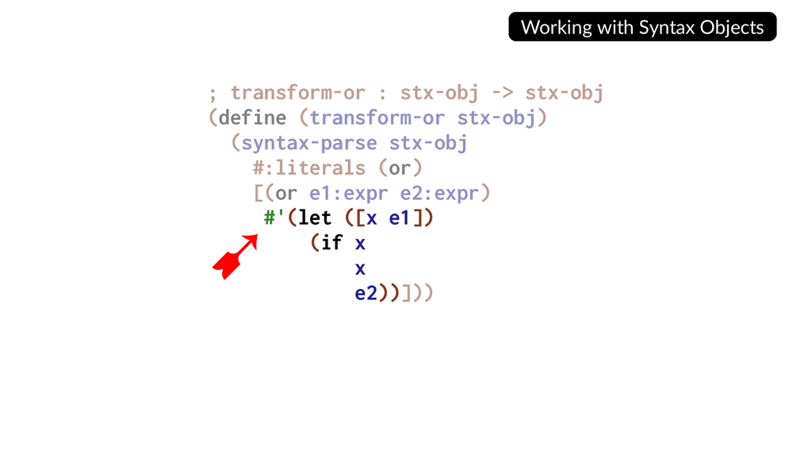

幻灯片 50：#' 引入要返回的语法对象Slide 50: #' introduces the syntax object to return

**幻灯片文字 / Slide text**

```
Working with Syntax Objects
; transform-or : stx-obj -> stx-obj
(define (transform-or stx-obj)
  (syntax-parse stx-obj
  #:literals (or)
  [(or e1:expr e2:expr)
#'(let ([x e1])
  (if x
x
e2))]))
➹
#'(let ([x e1])
  (if x
x
e2))
```

是的，我也应该承担一部分责任，因为 Redex 里也有这样的东西，不过，好吧。接下来，这就是主体。这里可以是任意的表达式。你看着可能觉得它是一个 let，但它不是 let，因为前面加了 #'。因此，它是一个语法对象。

Yes, I shouldn't I should I should get some of the blame for that one too because of because of Red X but okay. Um All right. So then that's the now this is the body. So this just is an arbitrary expression here. This might look like a let to you but it's not a let because it's prefixed with hash quote. And so therefore this is a syntax object.

所以，现在它是一棵有三个内部节点的树。前面我们已经讲过了。好，这就是我们要返回的东西，是我们要返回的数据结构。只不过，它为编写这种转换、编写这种数据结构提供了一种方便的记法。对，对，对，对。是的，你可以写 #`，只是我这里没写。不，是的，对。所以，好，没错，你已经预见到下一张幻灯片了。

So this is now a tree with the three interior nodes. We went through that before. Okay, so this is the thing that we're returning. This is the data structure that we're returning. It just has a nice notation for writing these transformations. That data structure. Yeah. Yeah. Yeah. Yeah. So, yeah. Yeah. Yeah. You can write hashback quote. Uh I just didn't. No. Uh yeah. Yeah. So, so okay. Right. Exactly. You anticipate the next slide.

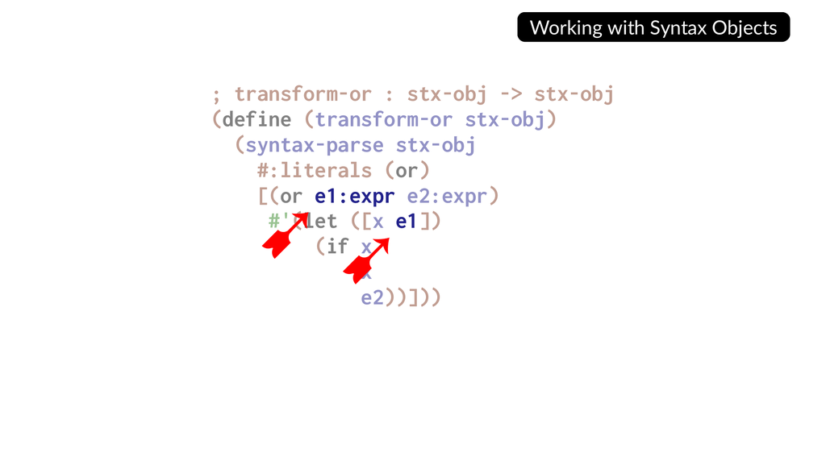

幻灯片 51：模式变量连接匹配过程与输出模板Slide 51: Pattern variables connect matching to the output template

**幻灯片文字 / Slide text**

```
Working with Syntax Objects
; transform-or : stx-obj -> stx-obj
(define (transform-or stx-obj)
  (syntax-parse stx-obj
  #:literals (or)
  [(or e1:expr e2:expr)
#'(let ([x e1])
  (if x
x
e2))]))
➹
e1
➹
e1:expr
```

syntax-parse 和 #' 会相互配合，使得通过 syntax-parse 的模式绑定的变量，在 #' 内出现时能够被查找到。因此，如果 E1 不是通过 syntax-parse 绑定的，你就需要用 #, 来取出它。但由于它是用 syntax-parse 绑定的，这些东西就可以直接放进去。它并不是字面意义上那样做的，不过，是这个意思。

The syntax parse and hash quote cooperate with each other so that variables bound by pattern syntax parse are looked up by occurrences inside hash quote. So if you if you bound it not with if you bound E1 not with syntax parse you would need to use hash comma to get it. But because it's bound with syntax parse then these guys are just you just can drop it in. It doesn't literally do that, but yes.

## 那么，那个 eval 呢？So, what about that eval?

事实是，syntax-parse 本身就是一个宏，它用到了我们正在讲的所有这些好东西，因此不必真的按你描述的方式来做。比如，这里就涉及 γ。不过我不打算……好，让我们……对，expr，准确地说是 expr，是否是在某处定义的东西？是的。expr 实际上是 syntax-parse 定义的一个东西，用来帮助它解析。在这里，它的意思是拒绝某些东西。

So, so it turns out that syntax parse is a macro and it's using all of these goodies we're doing to not have to literally do what you described. Like the gamma is involved here. Okay. But I'm not gonna Okay, let's Yeah. expert or rather expert is that yes some you have defined somewhere. Expert is actually something that syntax parse defines that helps it do the parsing. Here it means reject certain things.

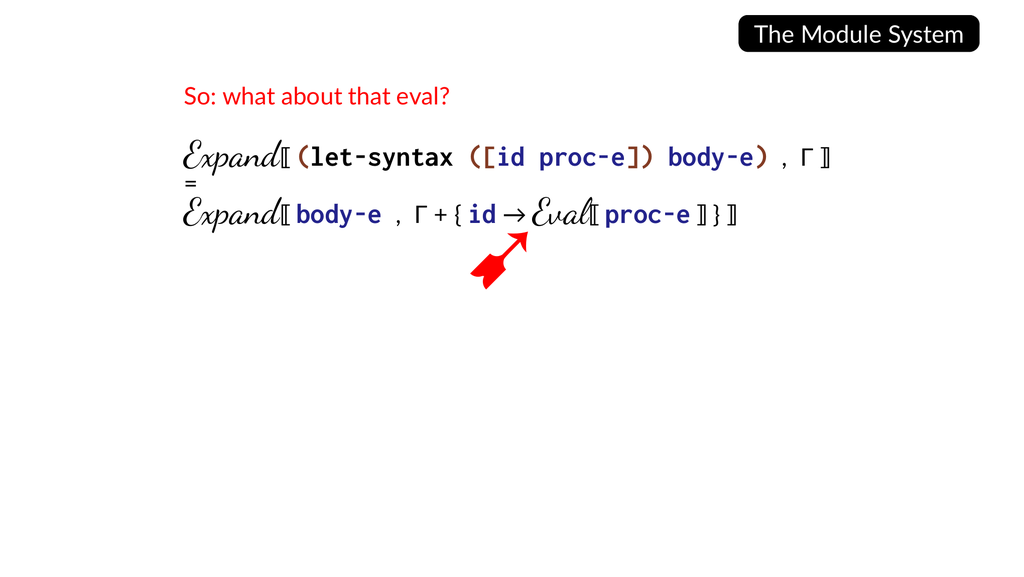

幻灯片 52：回到那个 Eval：转换器代码何时求值？Slide 52: Returning to Eval: when is transformer code evaluated?

**幻灯片文字 / Slide text**

```
The Module System
So: what about that eval?
Expand〚 (let-syntax ([id proc-e]) body-e) , Γ ⟧
=
Expand〚 body-e , Γ + { id → Eval
➹
〚 proc-e ⟧ } ⟧
```

它不会拒绝那些东西。比如关键字；语法里还有其他一些东西，它会拒绝那些东西。对，对，是的，关键字。好，好。那么，那个 eval 呢？顺便说一下，我们前面讲过 let-syntax，而从现在开始，我会使用 define-syntax。

It wouldn't reject those things. like keywords. There's there's more stuff in the syntax and it rejects those things. Yeah. Yeah. It's a Yeah, keywords. Yeah. Okay. Okay. So, what about that eval? Okay. Um so, sidebar, this let syntax that we talked about before, the we're going to use I'm gonna use define syntax from now on.

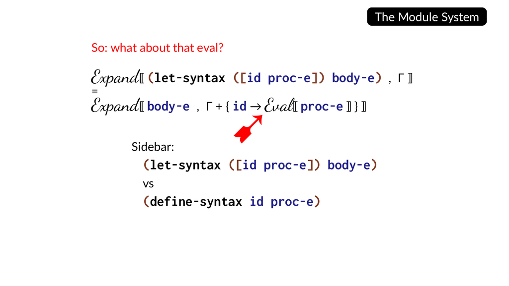

幻灯片 53：let-syntax 与 define-syntax 的作用范围Slide 53: The scope of let-syntax versus define-syntax

**幻灯片文字 / Slide text**

```
The Module System
So: what about that eval?
Expand〚 (let-syntax ([id proc-e]) body-e) , Γ ⟧
=
Expand〚 body-e , Γ + { id → Eval
➹
〚 proc-e ⟧ } ⟧
Sidebar:
(let-syntax ([id proc-e]) body-e)
vs
(define-syntax id proc-e)
```

这两者之间，以及展开器处理它们的方式之间，真正的区别只有一个：使用 let-syntax 时，你必须找到 body-e 的末尾，并在那里补上右括号；而使用 define-syntax 时，它基本上就一直延续到文件末尾。

The only really difference between these two and the way they're treated by the expander is that body e you have to go find the end of body e and put a close par when you're using let syntax whereas with defined syntax it just kind of goes to the end of the file basically.

实际上，它做的事情不止这些，不过对我们今天的讨论来说，把它理解成会继续往后延伸就可以了。所以，基本区别在于，你不必再去找 body-e，也不必在它的末尾加上右括号。好，我们仍然会把这个标识符放进环境里。

It's actually does more stuff than that but like for us today it's okay to just say oh it's just going to kind of keep going. So the body e you just so the basic difference here is that the body e you don't have to go find the body e and put the closed print at the end of it. Okay that's so we're still going to take this identifier and put it in the environment.

我们仍然会对 proc-e 求值，然后 expand 就会继续处理下面的内容。它实际所做的事情更复杂，因为还支持相互递归；为了支持这些功能，我前面展示的数据结构里实际上还有更多内容，而某些命令式的东西就藏在那里。今天我们不会深入。好，不过，这就是 define-syntax。

We're still going to evaluate procy and then and then expand is just going to kind of continue with what's below. Okay, the actual thing it does is more complex because there's some support for mutual recursion and then and there's actually more things in that data structure I showed you to support them and that's where some of the imperative stuff is hiding and we're not going to go there today. Okay, but so define syntax.

## 把定义语法改为 define-syntaxChanging the definition syntax to define syntax

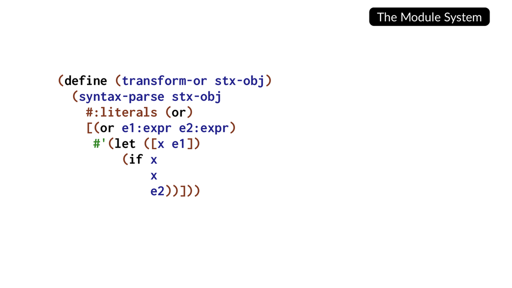

幻灯片 54：从普通的 transform-or 函数出发Slide 54: Starting with an ordinary transform-or function

**幻灯片文字 / Slide text**

[output not shown]

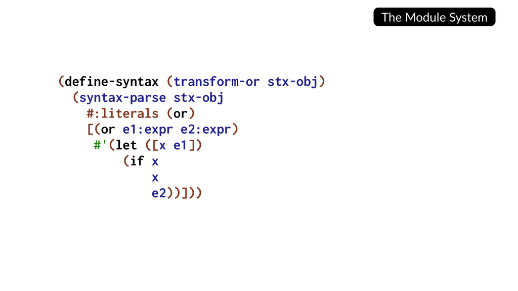

幻灯片 55：将 define 改为 define-syntaxSlide 55: Changing define to define-syntax

**幻灯片文字 / Slide text**

[output not shown]

如果我们拿来刚才费了好大功夫才读懂的那个函数，只把 define 改成 define-syntax，就得到了一个宏。好，这里用了一点简写，也就是那种函数简写。我相信你们能猜到它简写了什么：define-syntax，函数的名字，然后一个 lambda。这样，它看起来就符合 define-syntax 的形式了。

Um, so if we take this function we just like painstakingly went through to understand that code and we just changed the define into define syntax, we have a macro. Okay, there's a little bit of a shorthand happening here. This kind of function shorthand. I'm sure you can guess what this is short for. Um, it's defined syntax, the name of the function, and then a lambda. So now it looks like the defined syntax.

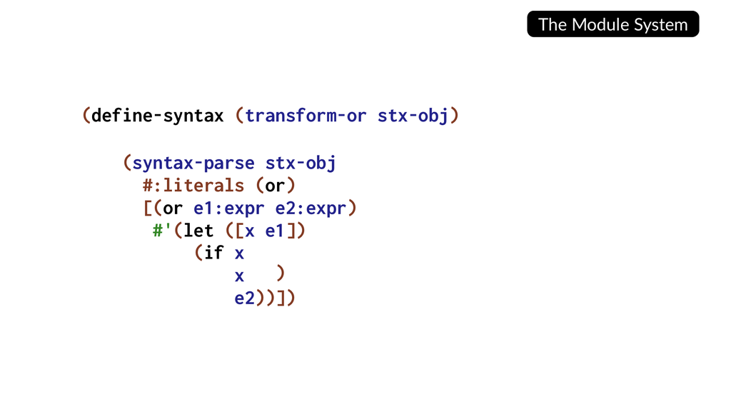

幻灯片 56：展开函数定义的简写Slide 56: Expanding the function-definition shorthand

**幻灯片文字 / Slide text**

[output not shown]

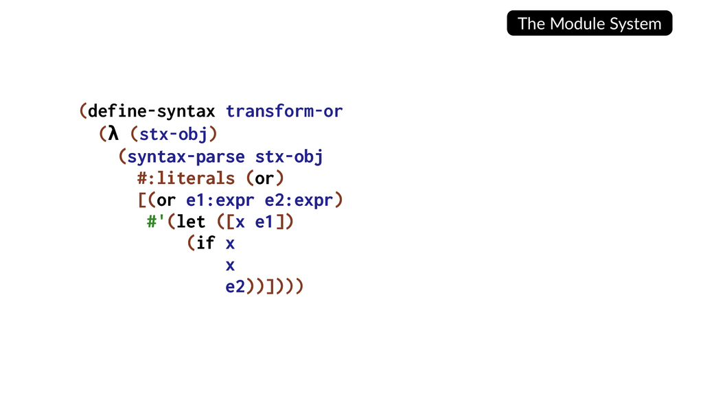

幻灯片 57：宏转换器是一个 lambda 值Slide 57: The macro transformer is a lambda value

**幻灯片文字 / Slide text**

```
The Module System
(define-syntax transform-or
  (λ (stx-obj)
  (syntax-parse stx-obj
  #:literals (or)
  [(or e1:expr e2:expr)
#'(let ([x e1])
  (if x
x
e2))])))
(syntax-parse stx-obj
  #:literals (or)
  [(or e1:expr e2:expr)
#'(let ([x e1])
  (if x
    x
    e2))])
```

它看起来就像展开器中的那个分支。所以，我们要做的事情是把这个名字放进环境里，映射到对这个表达式求值的结果。当然，对 lambda 表达式求值时，不会发生多少有趣的计算。但这个 lambda 的自由变量会引出一些非常有趣的问题，这也就把我们带到了第三个技术部分。

It looks like that case in the expander. So what we're going to do is we're going to put this thing into the environment mapped to evaluating this thing. Of course, when you evaluate a lambda expression, there's not a lot of interesting computation that happens there. But there is some very interesting questions about the free variables of this lambda and that's where we get to the third technical piece.

## 模块系统在编译期分析中的作用The Role of Module System in Compile Time Analysis

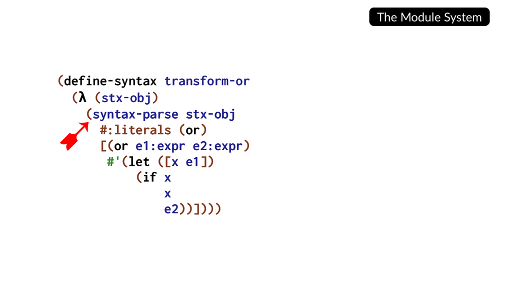

幻灯片 58：syntax-parse 自身必须在编译期可用Slide 58: syntax-parse itself must be available at compile time

**幻灯片文字 / Slide text**

```
The Module System
(define-syntax transform-or
  (λ (stx-obj)
  (syntax-parse stx-obj
  #:literals (or)
  [(or e1:expr e2:expr)
#'(let ([x e1])
  (if x
x
e2))])))
(syntax-parse
➹
stx-obj
  #:literals (or)
  [(or e1:expr e2:expr)
#'(let ([x e1])
  (if x
    x
    e2))])
```

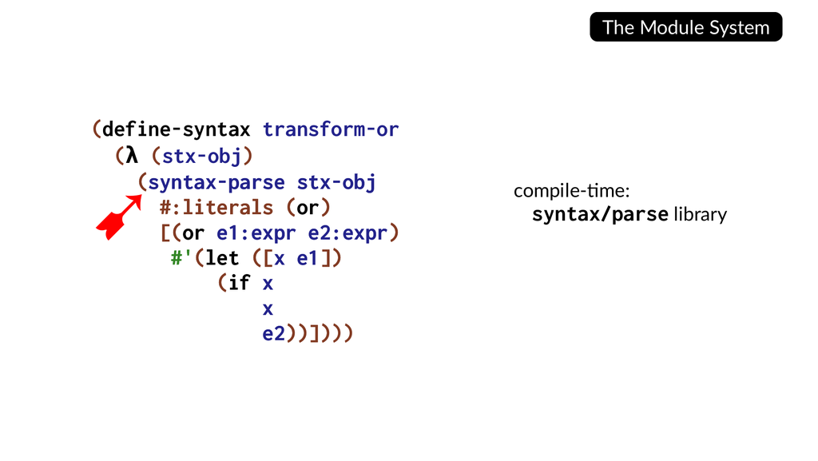

幻灯片 59：编译期依赖 syntax/parse 库Slide 59: The compile-time dependency on syntax/parse

**幻灯片文字 / Slide text**

```
The Module System
(define-syntax transform-or
  (λ (stx-obj)
  (syntax-parse stx-obj
  #:literals (or)
  [(or e1:expr e2:expr)
#'(let ([x e1])
  (if x
x
e2))])))
(syntax-parse
➹
stx-obj
  #:literals (or)
  [(or e1:expr e2:expr)
#'(let ([x e1])
  (if x
    x
    e2))])
compile-time:
syntax/parse library
```

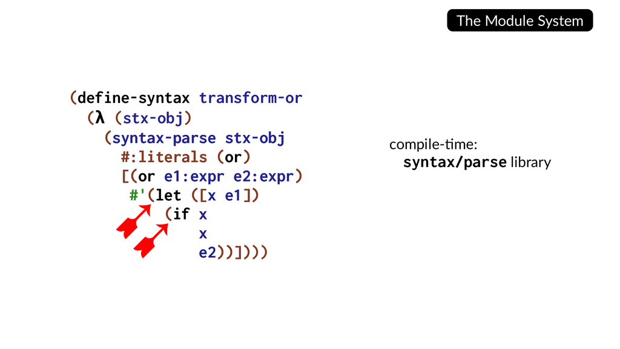

幻灯片 60：输出模板中的 let 和 if 属于运行期Slide 60: The let and if in the output template belong to run time

**幻灯片文字 / Slide text**

```
The Module System
(define-syntax transform-or
  (λ (stx-obj)
  (syntax-parse stx-obj
  #:literals (or)
  [(or e1:expr e2:expr)
#'(let ([x e1])
  (if x
x
e2))])))
(syntax-parse stx-obj
  #:literals (or)
  [(or e1:expr e2:expr)
#'(let
➹
([x e1])
  (if
➹
x
    x
    e2))])
compile-time:
syntax/parse library
```

现在，这个 syntax-parse 的实现，是我们在编译这段代码时需要的，对吧？所以我们需要它，而它位于 syntax/parse 库中。但如果考虑运行期需要什么，这里只用到了 let 和 if。因此，这个文件在运行期只需要基础功能。这就是模块系统开始发挥作用的地方。

Um so this syntax parse now that is we need the implementation of that at compile time of this code right. So we need the what's it's in the syntax/parse library. But if you think about what we need at runtime well we're just using let and if here. So at runtime of this file we just need the basics. So the this is where the module system comes in.

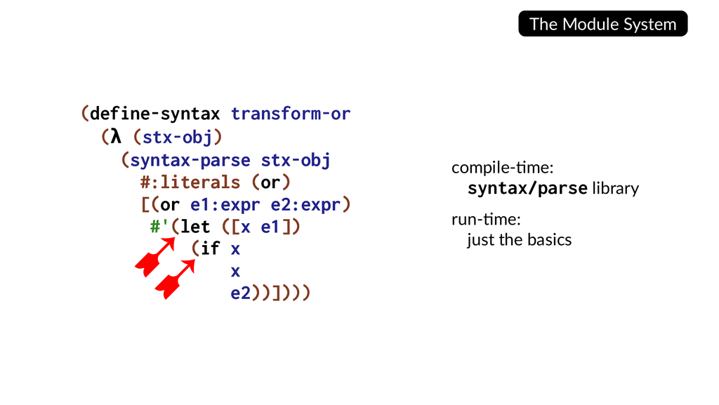

幻灯片 61：区分编译期依赖与运行期依赖Slide 61: Distinguishing compile-time and run-time dependencies

**幻灯片文字 / Slide text**

```
The Module System
(define-syntax transform-or
  (λ (stx-obj)
  (syntax-parse stx-obj
  #:literals (or)
  [(or e1:expr e2:expr)
#'(let ([x e1])
  (if x
x
e2))])))
(syntax-parse stx-obj
  #:literals (or)
  [(or e1:expr e2:expr)
#'(let
➹
([x e1])
  (if
➹
x
    x
    e2))])
compile-time:
syntax/parse library
run-time:
just the basics
```

它实际上会跟踪编译期的依赖，因此我们能知道，编译期需要哪些库，运行期又需要哪些库。不过，事情还要更复杂一点，因为正如我指出的，syntax-parse 本身就是一个宏。所以，这里面还涉及编译期的编译期。

It actually tracks the dependencies at compile time so that we can know what libraries we need at compile time and what libraries we need at runtime. But it's a little bit worse than that because as I pointed out syntax parse is itself a macro. So there's the compile time of the compile time involved here.

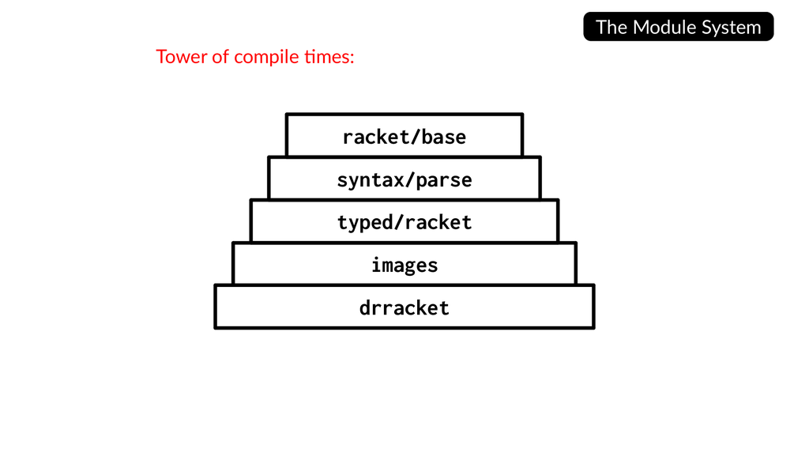

幻灯片 62：DrRacket 的编译期层级塔Slide 62: The tower of compile times in DrRacket

**幻灯片文字 / Slide text**

```
The Module System
Tower of compile times:
racket/base
syntax/parse
typed/racket
images
drracket
```

因此，模块系统基本上是一个依赖管理系统，能够跟踪这种层层叠加的编译期。好。出于好玩，我拿来 Racket 的 IDE，也就是 DrRacket 的实现，写了一个脚本，尽可能寻找最深的“编译期的编译期的编译期”层级。这里有五层。DrRacket 是运行期，然后是 images 库。

So the the module system is man is basically a dependency management system that can track this kind of towers of compile times. Okay. And just for fun, I got I took the implementation of Dr. Racket, which is Racket's IDE, and I wrote a script that finds the deepest compile time of the compile time of the compile time tower I could. And here's five layers. So, Dr. Racket, that's runtime. The images library.

不知道你们有没有注意到这里，看看上面那些小东西，我不知道，有一些漂亮的明暗效果和有趣的形状。哦，你们看不到鼠标，不过上面那些按钮确实有漂亮的明暗效果和一些有意思的细节。这是因为编译期运行了一个光线追踪器。因此，传给宏的参数，并不是某个普通的表达式。

So, I don't know if you noticed this here in but if you look at these like little things up here, I don't know, there's some like nice shading and interesting shapes happening. Oh, you can't see the mouse, but like there's some nice shading and interesting things happening on those buttons up there. Okay, that's because there's a ray tracer running at compile time. So, the argument to the macro is not like some expression.

传给宏的参数，是对形状、光源等东西的描述。宏会运行这些任意的 Racket 代码，生成位图的字节。所以，这件事发生在 DrRacket 的编译期。当然，为了争取更好的性能，这部分是用 Typed Racket 写的。因此，在那个编译期，我们需要类型检查器。而 Typed Racket 当然又使用了 syntax-parse。

The argument to the macro is a description of shapes and light sources and stuff. And the macro runs this arbitrary racket code to generate the bytes of a bit map. So, that's happening at compile time of dock racket. Of course, that's written in typed racket in order to try to get the performance. So we need at that compile time we need the type checker. Um typed bracket is of course using syntax parse.

所以，我们在那个编译期需要这个宏。然后，syntax-parse 当然又是用 Racket 编写的，所以还需要基础功能，才能真正执行那些底层的、针对归纳数据结构的操作。好，实际上，这只是我觉得能够向你们这些并未深入代码库的人解释清楚的五层。事实上，Typed Racket 自己内部还有两层。

So we need that macro at that compile time. And then of course syntax parse is written using racket. So we need like the basic stuff to be able to you know actually go into those low level inductive data structure operations at okay and actually this is a this is only the five that I felt like I could explain to y'all who aren't like deep in the codebase. In fact typed racket has its own internally two layers.

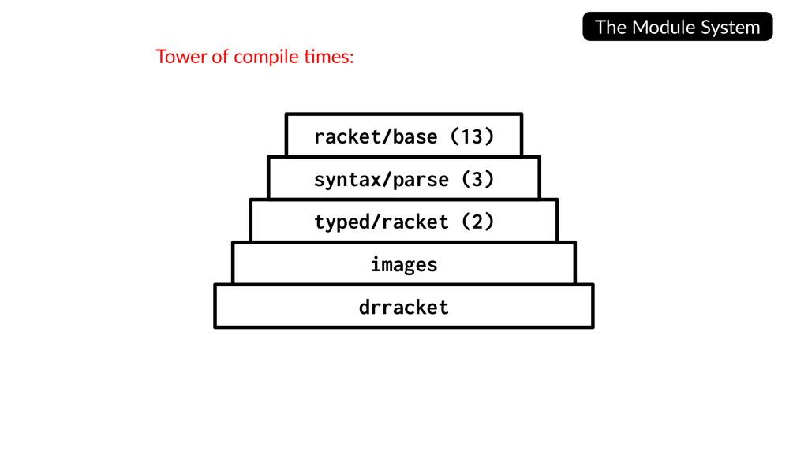

幻灯片 63：库内部还包含更多编译期层级Slide 63: Additional compile-time layers inside the libraries

**幻灯片文字 / Slide text**

```
The Module System
Tower of compile times:
racket/base (13)
syntax/parse (3)
typed/racket (2)
images
drracket
```

syntax-parse 自己有三层，而 racket/base 内部更是有夸张的十三层。这是因为 IR 实在太贫乏，所以你刚实现好一样东西，就会想：我需要在编译期使用它，来实现下一个东西。因此，上面还有许多小层次。总共深达二十层，而模块系统仍然必须处理它，处理所有这些依赖。好，这就是第三个技术部分。我不会解释模块系统的工作原理，你只要知道，它会替你完成这件事，而且采用声明式记法。这里实际上是一个完整的 Racket 文件。因为我们在编译期使用 syntax-parse，所以需要导入 syntax/parse 库，并用这个 for-syntax 关键字把它包起来。这表示，在编译期，我们既能使用 syntax/parse 库，也能使用基础功能。然后，因为这个模块在运行期需要 let 和 if，我们就在运行期 require 基础库，而不必在相应阶段之外 require syntax/parse，因此那个时候就不需要它了。